# SPARX: An Automated, Programmatically Generated Frequency-Scalable Six-Port Receiver in 130-nm CMOS

**Authors:** David Kellerer-Pirklbauer, Simon Dorrer, and Harald Pretl

**Institute:** Institute for Integrated Circuits and Quantum Computing, Johannes Kepler University (JKU), Linz, Austria

**Email:** {david.kellerer-pirklbauer, simon.dorrer, harald.pretl}@jku.at

**Index Terms:** Branch-line coupler, frequency-scalable layout, GDSFactory, Hairpin coupled-line bandpass filter, IHP-Open-PDK, mmWave, open-source EDA, power detector, programmatic layout, Schottky barrier diode, six-port receiver, Wilkinson power divider.

# Project Description

In this notebook, a tapeout-ready frequency-scalable mmWave six-port receiver is programmatically generated in Python using GDSFactory and the 130-nm IHP-Open-PDK with CMOS-only devices. **SPARX** stands for **S**ix-**P**ort **A**utomated Receiver (**RX**).

The goal of this project was to integrate the IHP-Open-PDK and self-made RF devices into GDSFactory to test its limits with an actual tapeout. During development, we pushed the design toward full frequency scalability, so changing the target frequency in the notebook automatically resizes the full RF layout.

The receiver consists of three branch-line couplers, a hairpin coupled-line bandpass filter, a Wilkinson power divider, and a power detector utilizing Schottky barrier diodes (SBDs).

# Block Diagram

The following block diagram visualizes the mmWave six-port receiver design.

[output not shown]

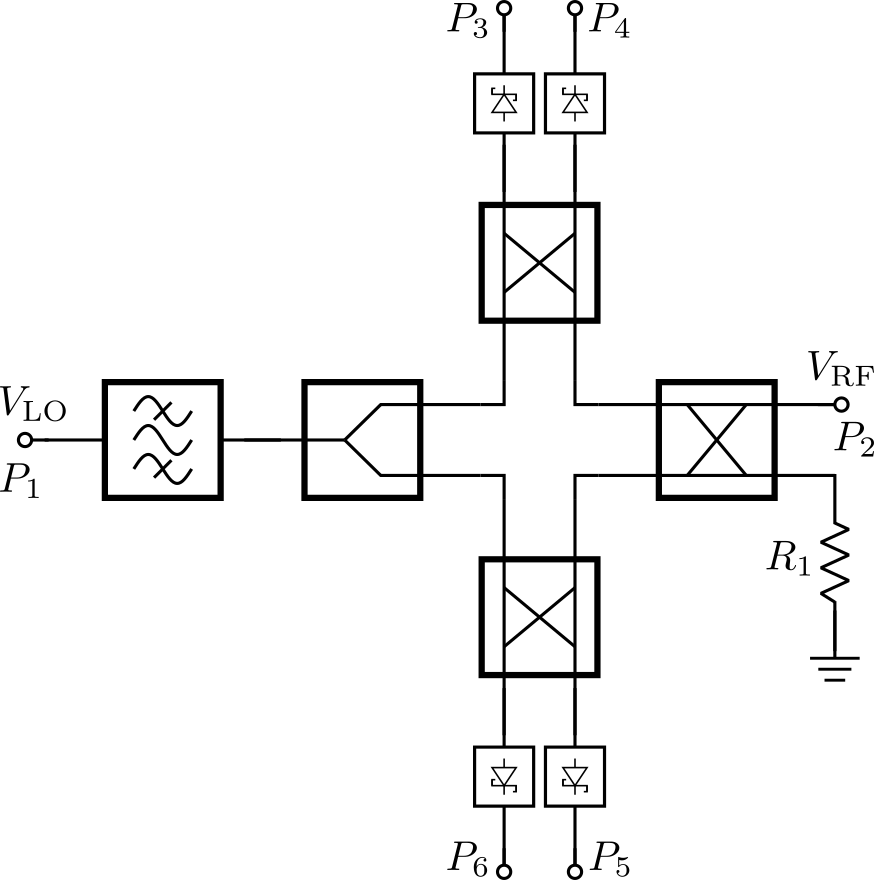

```python
# download all necessary assets
! git clone --depth 1 --filter=blob:none --sparse https://github.com/iic-jku/SG13G2_SPARX.git /tmp/repo
! cd /tmp/repo && git sparse-checkout set sscs-ose-code-a-chip/assets
! mv /tmp/repo/sscs-ose-code-a-chip/assets /tmp/assets
! rm -rf /tmp/repo

from IPython.display import Image, display
display(Image(filename="/tmp/assets/sparx_blockdiagram.png", width=576))
```

# Video Demonstration

In the following video, the generation of six-port receivers from 60 GHz to 300 GHz in under one minute is demonstrated.

```python
from IPython.display import Video, display
display(Video(filename="/tmp/assets/sparx_gen_60ghz_to_300ghz.mp4", embed=True, mimetype="video/mp4", width=1024))
```

[video not shown]

# References

To understand the principle of six-port receivers and their architectures, it is recommended to read the following references:

- A. Koelpin, G. Vinci, B. Laemmle, D. Kissinger and R. Weigel, "The Six-Port in Modern Society," in IEEE Microwave Magazine, vol. 11, no. 7, pp. 35-43, Dec. 2010, doi: 10.1109/MMM.2010.938584: https://ieeexplore.ieee.org/document/5590352
- T. Hentschel, "The six-port as a communications receiver," in IEEE Transactions on Microwave Theory and Techniques, vol. 53, no. 3, pp. 1039-1047, March 2005, doi: 10.1109/TMTT.2005.843507: https://ieeexplore.ieee.org/document/1406309
- M. Mailand, "System Analysis of Six-Port-Based RF-Receivers," in IEEE Transactions on Circuits and Systems I: Regular Papers, vol. 65, no. 1, pp. 319-330, Jan. 2018, doi: 10.1109/TCSI.2017.2734922: https://ieeexplore.ieee.org/document/8011483

# Requirements

To build this six-port receiver, the following tools and their respective dependencies are required:

- GDSFactory: https://github.com/gdsfactory/gdsfactory
- Updated IHP-Open-PDK GDSFactory version: https://github.com/iic-jku/IHP
- IHP-Open-PDK: https://github.com/iic-jku/IHP-Open-PDK

The updated IHP-Open-PDK GDSFactory version contains all self-made RF devices and wraps existing PCells provided by the IHP-Open-PDK, allowing them to be used directly within the GDSFactory framework. We choose this approach because it requires very little maintenance. If IHP changes the layout of a cell, no wrapper update is necessary. Only interface changes to a PCell function require updates on our side.

> **Note:** This notebook only demonstrates the layout generation of the six-port receiver. For the full design flow, refer to the [official SPARX GitHub repository](https://github.com/iic-jku/SG13G2_SPARX), which includes S-parameter simulation of the passive RF structures with AWS Palace, a complete LVS, DRC, and RCX verification flow using KLayout, Magic, and Netgen, and SBD-based power detector design in Xschem with ngspice and VACASK simulation. The entire flow is controlled by a Makefile. Simply install the IIC-OSIC-TOOLS container from JKU, clone the repository and run `make all` to build and verify the six-port receiver at any target frequency.

**Installation of IHP-Open-PDK GDSFactory version:**

First, our GDSFactory integration of the IHP-Open-PDK is cloned and installed. This IHP-Open-PDK version contains all self-made RF devices and wraps existing PCells provided by the IHP-Open-PDK, allowing them to be used directly within the GDSFactory framework. We choose this approach because it requires very little maintenance. If IHP changes the layout of a cell, no wrapper update is necessary. Only interface changes to a PCell function require updates on our side.

Running `pip install -q $IHP_DIR` installs the required Python dependencies automatically.

```python
%env PDK_ROOT=/tmp/pdks
%env IHP_DIR=/tmp/ihp
! rm -rf $IHP_DIR && git clone -q --depth 1 -b IHP-TO https://github.com/iic-jku/IHP.git $IHP_DIR
! find $IHP_DIR -name '*.py' -type f -exec sed -i.bak "s|/foss/pdks|$PDK_ROOT|g" {} + && find $IHP_DIR -name '*.bak' -delete
%pip install -q $IHP_DIR
%pip install --upgrade "schemdraw[svgmath]" ziamath
```

```
env: PDK_ROOT=/tmp/pdks
env: IHP_DIR=/tmp/ihp
```

**Installation of IHP-Open-PDK:**

Next, the IHP-Open-PDK itself is cloned and placed in the correct folder. The IHP-Open-PDK provides the technology files required for layout generation.

```python
! rm -rf $PDK_ROOT && mkdir -p $PDK_ROOT
! git clone -q --depth 1 https://github.com/iic-jku/IHP-Open-PDK.git $PDK_ROOT
! cd $PDK_ROOT && git checkout dev -q && git submodule update -q --init --recursive
```

**Import of Python Modules:**

```python
import gdsfactory as gf
import ihp
from pathlib import Path
import scipy
from math import sqrt
import klayout.db as kdb

ihp.PDK.activate()
```

# Power Detector Design based on Schottky Barrier Diodes

**Circuit Operation:**

- **R1** provides a 50 Ω input termination.
- **C1** ac-couples the RF + LO signal to the demodulating SBD **D1** and is implemented as a MIM capacitor.
- **M3 (= 10 M1) – M4 (= 10 M2)** and **R2** form a transimpedance amplifier (TIA) that delivers a buffered voltage output.
- **M1–M2**, **D2 (= D1)**, and **R4 (= R2) – R5 (= R1)** implement a replica bias. With this replica circuit, it is now possible to measure the demodulated output signal differentially.
- **C2-C4** are MIM capacitor arrays that provide proper decoupling of the supply rail and bias voltages (not shown in the schematic).

**Layout Considerations:**

- Minimize RF input parasitics (R, L, C):
  - Route TopMetal2 directly down to the top plate (TopMetal1) of C1with a VIA.
  - Use a VIA-stack from the bottom plate (Metal5) of C1 directly down to the SBD.
- Apply **Metal5 no-fill regions** to reduce parasitic capacitance.
- Match components of the main and replica paths.
- **C2–C4** values may be adapted to layout requirements, provided they remain large enough for sufficient supply-rail decoupling.

> In the following code block, the SBD-based power detector (PD) is defined as a standalone `@gf.cell` function. This modular approach enables the same detector design to be reused across all four output channels.

```python
# Drawing of SBD-based Power Detector
import matplotlib
matplotlib.rcParams.update({
    "mathtext.fontset": "cm",
    "font.family": "serif",
})
import schemdraw as sd
import schemdraw.elements as elm
sd.svgconfig.svg2 = False

with sd.Drawing() as d:
    d.config(unit=2, fontsize=16)

    # Vrf Input, C1, D1
    Vrf = elm.Dot(open=True).label(r'$V_\mathrm{rf}$', loc='left', ofst=0.15)
    elm.Line().right().length(1.0)
    C1 = elm.Capacitor().right().label(r'$C_\mathrm{1}$', loc='top', ofst=0.15)
    elm.Line().right().length(1.0)
    node_rfin_int = elm.Dot().label(r'$1.128\,\mathrm{V}$', loc='bottom', ofst=0.15)
    elm.Line().right().length(1.0)
    D1 = elm.Schottky().right().label(r'$D_\mathrm{1}$', loc='top', ofst=0.15)
    elm.Line().right().length(1.0)
    node_bb_int = elm.Dot().label(r'$0.756\,\mathrm{V}$', loc='bottom', ofst=(-0.75, -0.15))

    # R1, R3, VDD
    elm.Line().at(node_rfin_int.end).up().length(1.0)
    R1 = elm.Resistor().up().label(r'$R_\mathrm{1}$', loc='top', ofst=0.15)
    node_bias1 = elm.Line().up().length(1.0).dot().label(r'$1.129\,\mathrm{V}$', loc='right', ofst=0.15)
    elm.Line().left().length(0.5)
    R3 = elm.Resistor().left().label(r'$R_\mathrm{3}$', loc='top', ofst=0.15)
    elm.Line().left().length(0.5)
    node_vdd = elm.Line().up().length(1.5).dot()
    elm.Dot().label(r'$1.5\,\mathrm{V}$', loc='top', ofst=0.15)
    elm.Line().left().tox(Vrf.start)
    vdd = elm.Dot(open=True).label(r'$V_\mathrm{DD}$', loc='left', ofst=0.15)

    # M3, M4, R2, VSS
    elm.Line().at(node_bb_int.end).right().length(0.5)
    R2 = elm.Resistor().right().label(r'$R_\mathrm{2}$', loc='top', ofst=0.15)
    elm.Line().right().length(0.5)
    node_vout = elm.Dot().label(r'$0.730\,\mathrm{V}$', loc='bottom', ofst=(0.85, -0.15))
    elm.Line().down().length(1.0)
    M3 = elm.AnalogNFet(offset_gate=False).anchor('drain').theta(0).label(r'$10\,M_\mathrm{1}$', loc='right', ofst=0.15).reverse()
    elm.Line().at(M3.source).down().length(1.0)
    elm.Dot().label(r'$4\,\mathrm{mA}$', loc='bottom', ofst=0.15)
    elm.Line().left().tox(Vrf.start)
    vss = elm.Dot(open=True).label(r'$V_\mathrm{SS}$', loc='left', ofst=0.15)
    elm.Line().at(M3.gate).left().tox(node_bb_int.end)
    elm.Line().up().toy(node_bb_int.end)
    elm.Line().at(node_vout.end).up().length(1.0)
    M4 = elm.AnalogPFet(offset_gate=False).anchor('drain').theta(0).label(r'$10\,M_\mathrm{2}$', loc='right', ofst=0.15).reverse()
    elm.Line().at(M4.source).up().toy(node_vdd.end).dot()
    elm.Line().left().tox(node_vdd.end)
    elm.Line().at(M4.gate).left().tox(node_bb_int.end)
    elm.Line().down().toy(node_bb_int.end)
    elm.Line().at(node_vout.end).right().length(2.0)
    Vout = elm.Dot(open=True).label(r'$V_\mathrm{out}$', loc='right', ofst=0.15)

    # Replica Circuit: R5, D2, R4, M1, M2
    elm.Line().at(node_bias1.end).right().length(21.0)
    elm.Line().down().length(1.0)
    R5 = elm.Resistor().down().label(r'$R_\mathrm{1}$', loc='top', ofst=0.15)
    elm.Line().down().length(1.0)
    elm.Line().left().length(1.0)
    D2 = elm.Schottky().left().label(r'$D_\mathrm{1}$', loc='top', ofst=0.15)
    elm.Line().left().length(1.0)
    node_bias2 = elm.Dot().label(r'$0.761\,\mathrm{V}$', loc='bottom', ofst=(0.85, -0.15))
    elm.Line().at(node_bias2.end).left().length(0.5)
    R4 = elm.Resistor().left().label(r'$R_\mathrm{2}$', loc='top', ofst=0.15)
    elm.Line().left().length(0.5)
    node_vref = elm.Dot().label(r'$0.737\,\mathrm{V}$', loc='bottom', ofst=(-0.75, -0.15))
    elm.Line().down().length(1.0)
    M1 = elm.AnalogNFet(offset_gate=False).anchor('drain').theta(0).label(r'$M_\mathrm{1}$', loc='left', ofst=0.15)
    elm.Line().at(M1.source).down().toy(vss.end).label(r'$400\,\mu\mathrm{A}$', loc='left', ofst=0.15)
    elm.Line().left().tox(node_vout.end)
    elm.Line().at(M1.gate).right().tox(node_bias2.end)
    elm.Line().up().toy(node_bias2.end)
    elm.Line().at(node_vref.end).up().length(1.0)
    M2 = elm.AnalogPFet(offset_gate=False).anchor('drain').theta(0).label(r'$M_\mathrm{2}$', loc='left', ofst=0.15)
    elm.Line().at(M2.source).up().toy(node_vdd.end)
    elm.Line().left().tox(node_vout.end)
    elm.Line().at(M2.gate).right().tox(node_bias2.end)
    elm.Line().down().toy(node_bias2.end)
    elm.Line().at(node_vref.end).left().length(2.0)
    Vref = elm.Dot(open=True).label(r'$V_\mathrm{ref}$', loc='left', ofst=0.15)
```

[figure not shown]

```python
@gf.cell
def powdet_sbd() -> gf.Component:
    c = gf.Component("powdet_sbd")

    # via from rfin on TM2 to C1 on TM1
    via_TM1_TM2 = ihp.cells.via_stack(
        top_layer="TopMetal2",
        bottom_layer="TopMetal1",
        vt2_columns=4,
        vt2_rows=3,
    )
    via_TM1_TM2.ports["bottom"].orientation = 0
    via_TM1_TM2_ref = c.add_ref(via_TM1_TM2)
    # reference cmim capacitor and connect to via
    cmim = ihp.cells.cmim(width=10, length=10)
    C1_ref = c.add_ref(cmim)
    C1_ref.connect("T", via_TM1_TM2_ref.ports["bottom"], allow_width_mismatch=True)
    c.add_label(text="rfin", layer=ihp.tech.LAYER.TopMetal2text, position=via_TM1_TM2_ref.ports["top"].center)
    pin_marker_rfin = c.add_ref(gf.components.rectangle(layer=ihp.tech.LAYER.TopMetal2pin, size=(0.5,0.5)))
    pin_marker_rfin.center = via_TM1_TM2_ref.ports["top"].center

    # via cell from Metal2 to Metal5
    via_M2_M5 = ihp.cells.via_stack(
        top_layer="Metal5",
        bottom_layer="Metal2",
        vn_columns=6,
        vn_rows=3,
    )

    # via from CMIM C1 to XQ1
    via_M2_M5.ports["top"].orientation = 0
    via_M2_M5_ref = c.add_ref(via_M2_M5)
    via_M2_M5_ref.connect("top", C1_ref.ports["B"], allow_width_mismatch=True)

    # create D1 and connect to rfin via C1 and the vias
    schottky = ihp.cells.schottky()
    schottky.locked = False
    schottky.add_label(text="schottky_nbl1", layer=ihp.tech.LAYER.TEXTdrawing)

    D1_ref = c.add_ref(schottky)
    D1_ref.connect("e4", via_M2_M5_ref.ports["bottom"], allow_width_mismatch=True, allow_layer_mismatch=True)

    # create D2 and place nearby D1 for better matching
    D2_ref = c.add_ref(schottky)
    D2_ref.ymin = D1_ref.ymin
    D2_ref.xmin = D1_ref.xmax

    # create capasitor array for cap 2
    C2 = gf.Component("C2")
    cmim = ihp.cells.cmim(width=10, length=10)
    cap_connection_thickness = 4 # thickness of the metal connection between caps, adjust as needed

    # create the array of cmim capacitors for C2 with column pitch of 0.52 + 11.2 to fit the required spacing for TM1 and the size of the caps
    spacing_between_caps = 0.52
    top_row = C2.add_ref(gf.components.array(component=cmim, columns=6, rows=1, column_pitch= spacing_between_caps + 11.2))

    middle_row = C2.add_ref(gf.components.array(component=cmim, columns=6, rows=1, column_pitch= spacing_between_caps + 11.2))
    bottom_row = C2.add_ref(gf.components.array(component=cmim, columns=6, rows=3, column_pitch= spacing_between_caps + 11.2, row_pitch= -(spacing_between_caps + 11.2)))
    top_row.ymin = middle_row.ymax + spacing_between_caps # min spacing according to design rules 5.17
    bottom_row.ymax = middle_row.ymin - spacing_between_caps # min spacing according to design rules 5.17
    C2.add_ports(top_row.ports, prefix="TR_")
    C2.add_ports(middle_row.ports, prefix="MR_")
    C2.add_ports(bottom_row.ports, prefix="BR_")

    C2.add_label(text="vss", layer=ihp.tech.LAYER.Metal5text, position=C2.ports["BR_T_1_1"].center)
    pin_marker_vss = C2.add_ref(gf.components.rectangle(layer=ihp.tech.LAYER.Metal5pin, size=(0.5,0.5)))
    pin_marker_vss.center = C2.ports["BR_T_1_1"].center
    # orient the outer most port of top and bottom row to look inward to make a horizontal connection between each cap

    C2.ports["TR_T_1_1"].orientation = 0
    C2.ports["TR_B_1_1"].orientation = 0
    C2.ports["MR_T_1_1"].orientation = 0
    C2.ports["MR_B_1_1"].orientation = 0
    C2.ports["BR_T_1_1"].orientation = 0
    C2.ports["BR_B_1_1"].orientation = 0
    C2.ports["BR_T_2_1"].orientation = 0
    C2.ports["BR_B_2_1"].orientation = 0
    C2.ports["BR_T_3_1"].orientation = 0
    C2.ports["BR_B_3_1"].orientation = 0

    C2.ports["TR_T_1_6"].orientation = 180
    C2.ports["TR_B_1_6"].orientation = 180
    C2.ports["MR_T_1_6"].orientation = 180
    C2.ports["MR_B_1_6"].orientation = 180
    C2.ports["BR_T_1_6"].orientation = 180
    C2.ports["BR_B_1_6"].orientation = 180
    C2.ports["BR_T_2_6"].orientation = 180
    C2.ports["BR_B_2_6"].orientation = 180
    C2.ports["BR_T_3_6"].orientation = 180
    C2.ports["BR_B_3_6"].orientation = 180

    C2_connection_T = gf.routing.route_bundle_electrical(
        component=C2,
        ports1=[C2.ports["TR_T_1_1"],C2.ports["BR_T_2_1"],C2.ports["BR_T_3_1"], C2.ports["MR_T_1_1"], C2.ports["BR_T_1_1"]],
        ports2=[C2.ports["TR_T_1_6"],C2.ports["BR_T_2_6"],C2.ports["BR_T_3_6"], C2.ports["MR_T_1_6"], C2.ports["BR_T_1_6"]],
        route_width=cap_connection_thickness,
        layer=ihp.tech.LAYER.TopMetal1drawing,
        allow_layer_mismatch=True,
        allow_width_mismatch=True,
        auto_taper=False,
        separation=0,
    )

    C2_connection_B = gf.routing.route_bundle_electrical(
        component=C2,
        ports1=[C2.ports["TR_B_1_1"],C2.ports["BR_B_2_1"],C2.ports["BR_B_3_1"], C2.ports["MR_B_1_1"], C2.ports["BR_B_1_1"]],
        ports2=[C2.ports["TR_B_1_6"],C2.ports["BR_B_2_6"],C2.ports["BR_B_3_6"], C2.ports["MR_B_1_6"], C2.ports["BR_B_1_6"]],
        route_width=cap_connection_thickness,    # min width for metal1
        layer=ihp.tech.LAYER.Metal5drawing,
        allow_layer_mismatch=True,
        allow_width_mismatch=True,
        auto_taper=False,
        separation=0,
    )

    # orient top row ports to face downwards to connect to bottom row ports
    ihp.cells.utils.change_port_orientation(C2, ["TR_T_1_1", "TR_T_1_2", "TR_T_1_3", "TR_T_1_4", "TR_T_1_5", "TR_T_1_6"], 270)
    ihp.cells.utils.change_port_orientation(C2, ["TR_B_1_1", "TR_B_1_2", "TR_B_1_3", "TR_B_1_4", "TR_B_1_5", "TR_B_1_6"], 270)

    # orient bottom row ports to face downwards to connect to top row ports
    ihp.cells.utils.change_port_orientation(C2, ["BR_T_3_1", "BR_T_3_2", "BR_T_3_3", "BR_T_3_4", "BR_T_3_5", "BR_T_3_6"], 90)
    ihp.cells.utils.change_port_orientation(C2, ["BR_B_3_1", "BR_B_3_2", "BR_B_3_3", "BR_B_3_4", "BR_B_3_5", "BR_B_3_6"], 90)

    C2_connection_top = gf.routing.route_bundle_electrical(
        component=C2,
        ports1=[C2.ports["BR_T_3_1"], C2.ports["BR_T_3_2"], C2.ports["BR_T_3_3"], C2.ports["BR_T_3_4"], C2.ports["BR_T_3_5"], C2.ports["BR_T_3_6"]],
        ports2=[C2.ports["TR_T_1_1"], C2.ports["TR_T_1_2"], C2.ports["TR_T_1_3"], C2.ports["TR_T_1_4"], C2.ports["TR_T_1_5"], C2.ports["TR_T_1_6"]],
        route_width=cap_connection_thickness,    # adjust for thicker connections
        layer=ihp.tech.LAYER.TopMetal1drawing,
        allow_layer_mismatch=True,
        allow_width_mismatch=True,
        auto_taper=False,
        separation=0,
    )
```

```python
    C2_connection_bottom = gf.routing.route_bundle_electrical(
        component=C2,
        ports1=[C2.ports["BR_B_3_1"], C2.ports["BR_B_3_2"], C2.ports["BR_B_3_3"], C2.ports["BR_B_3_4"], C2.ports["BR_B_3_5"], C2.ports["BR_B_3_6"]],
        ports2=[C2.ports["TR_B_1_1"], C2.ports["TR_B_1_2"], C2.ports["TR_B_1_3"], C2.ports["TR_B_1_4"], C2.ports["TR_B_1_5"], C2.ports["TR_B_1_6"]],
        route_width=cap_connection_thickness,    # adjust for thicker connections
        layer=ihp.tech.LAYER.Metal5drawing,
        allow_layer_mismatch=True,
        allow_width_mismatch=True,
        auto_taper=False,
        separation=0,
    )

    # orient top row ports to face upwards to connect the ground plates to the other caps
    ihp.cells.utils.change_port_orientation(C2, ["TR_B_1_1", "TR_B_1_2", "TR_B_1_3", "TR_B_1_6"], 90)
    ihp.cells.utils.change_port_orientation(C2, ["TR_T_1_6"], 0) # for connection to bias1
    ihp.cells.utils.change_port_orientation(C2, ["BR_B_3_4", "BR_B_3_5"], 270)

    C2_ref = c.add_ref(C2)
    C2_ref.rotate(-90)
    C2_ref.center = C1_ref.center
    C2_ref.ymin = C1_ref.ymax + 10
    C2_ref.xmax = C1_ref.xmax + C1_ref.xsize + 0.52

    ## end of C2 generation

    r_sil = ihp.cells.rsil(
        width=0.5,
        length=2.5)

    # let the ports of XR1 and XR5 face each other for easier routing
    r_sil.ports["e2"].orientation = 0
    XR1_ref = c.add_ref(r_sil.copy())

    r_sil.ports["e2"].orientation = 180
    XR5 = r_sil.copy()
    XR5_ref = c.add_ref(XR5)


    # spacing between D1 and XR1/XR5
    spacing = 1
    XR1_ref.xmax = D1_ref.xmax - 1.88
    XR1_ref.ymax = D1_ref.ymin - spacing

    XR5_ref.xmin = D2_ref.xmin + 1.88
    XR5_ref.ymin = XR1_ref.ymin

    route_XR1_XR5 = gf.routing.route_bundle_electrical(
        component=c,
        ports1=[XR1_ref.ports["e2"]],
        ports2=[XR5_ref.ports["e2"]],
        route_width=0.26,    # min width for metal1
        layer=ihp.tech.LAYER.Metal1drawing,
        allow_layer_mismatch=True,
        allow_width_mismatch=True,
        auto_taper=False,
        separation=0,
    )

    # via for connection D1 to XR1 and XR5 to D2
    via_M1_M2 = ihp.cells.via_stack(
        top_layer="Metal2",
        bottom_layer="Metal1",
        vn_columns=6,
        vn_rows=2,
    )

    # via D1 -> XR1
    via_M1_M2.ports["top"].orientation = 90
    via_M1_M2.ports["bottom"].orientation = 0
    via_M1_M2_ref = c.add_ref(via_M1_M2.copy())
    via_M1_M2_ref.center = D1_ref.center
    via_M1_M2_ref.ymax = D1_ref.ymin

    # route from D1 to via
    route = gf.routing.route_bundle_electrical(
        component=c,
        ports1=[D1_ref.ports["e4"]],
        ports2=[via_M1_M2_ref.ports["top"]],
        route_width=max(via_M1_M2_ref.xsize, via_M1_M2_ref.ysize),
        layer=ihp.tech.LAYER.Metal2drawing,
        allow_layer_mismatch=True,
        allow_width_mismatch=True,
        auto_taper=False,
        separation=0,
    )


    # route from via to XR1
    route = gf.routing.route_bundle_electrical(
        component=c,
        ports1=[via_M1_M2_ref.ports["bottom"]],
        ports2=[XR1_ref.ports["e1"]],
        route_width=min(via_M1_M2_ref.xsize, via_M1_M2_ref.ysize),
        layer=ihp.tech.LAYER.Metal1drawing,
        allow_layer_mismatch=True,
        allow_width_mismatch=True,
        auto_taper=False,
        separation=0,
    )

    # connect second diode to input resistors
    # via D2 -> XR5
    via_M1_M2.ports["top"].orientation = 90
    via_M1_M2.ports["bottom"].orientation = 180
    via_M1_M2_ref = c.add_ref(via_M1_M2.copy())
    via_M1_M2_ref.center = D2_ref.center
    via_M1_M2_ref.ymax = D2_ref.ymin

    # route from D2 to via
    route = gf.routing.route_bundle_electrical(
        component=c,
        ports1=[D2_ref.ports["e4"]],
        ports2=[via_M1_M2_ref.ports["top"]],
        route_width=max(via_M1_M2_ref.xsize, via_M1_M2_ref.ysize),
        layer=ihp.tech.LAYER.Metal2drawing,
        allow_layer_mismatch=True,
        allow_width_mismatch=True,
        auto_taper=False,
        separation=0,
    )

    # route from via to XR5
    route = gf.routing.route_bundle_electrical(
        component=c,
        ports1=[via_M1_M2_ref.ports["bottom"]],
        ports2=[XR5_ref.ports["e1"]],
        route_width=min(via_M1_M2_ref.xsize, via_M1_M2_ref.ysize),
        layer=ihp.tech.LAYER.Metal1drawing,
        allow_layer_mismatch=True,
        allow_width_mismatch=True,
        auto_taper=False,
        separation=0,
    )


    ## build transimpedance amplifier with the schottky diode as input device
    # M1 nmos and M2 pmos each have 10 gates, M3 and M4 have one gate each, all nmos are placed together and so are the pmos
    ng_mos = 13 # 10 + 1 = 11, plus 2 dummy transistors for better matching
    ng_mos = 24 # 20 + 2 + 2 = 24, M1 + M3 + 2 dummy for nmos, M2 + M4 + 2 dummy for pmos
    width_nmos = 60 # um
    width_pmos = 120

    c_output = gf.Component("output_stage")

    M1_3 = ihp.cells.nmos(
        w=width_nmos,
        l=0.13,
        ng=ng_mos,
        guardRingType="psub",
        guardRingDistance=2,
    )

    via_gat_M1 = ihp.cells.via_stack(
            top_layer="Metal1",
            bottom_layer="GatPoly",
            vn_columns=1,
            vn_rows=2,
        )

    via_gat_M2 = ihp.cells.via_stack(
            top_layer="Metal2",
            bottom_layer="GatPoly",
            vn_columns=1,
            vn_rows=3,
        )

    via_gat_M3 = ihp.cells.via_stack(
            top_layer="Metal3",
            bottom_layer="GatPoly",
            vn_columns=1,
            vn_rows=3,
        )

    M1_3.locked=False
    via_gat_M1.ports["bottom"].orientation = 90
    via_gat_M2.ports["bottom"].orientation = 90
    via_gat_M3.ports["bottom"].orientation = 90
    via_gat_M3.ports["top"].orientation = 270 # turn top port for later connection
    gate_ports = M1_3.get_ports_list(layer=ihp.tech.LAYER.GatPolydrawing)
    gate_straight = ihp.cells.straight(
        length= 2.15,
        cross_section="gatpoly_routing",
        width=0.13 # manual meassure of the heigth of the via
    )
    gate_via_refs_nmos = []
    for i, p in enumerate(gate_ports):
        if p.name in ["G_1", "G_24"]: # these gates will be connected to metal1
            gate_via_refs_nmos.append(M1_3.add_ref(via_gat_M2))
        elif p.name in ["G_12", "G_13"]: # these gates will be connected to metal2
            gate_via_refs_nmos.append(M1_3.add_ref(via_gat_M2))
        else: # all others to metal3
            gate_via_refs_nmos.append(M1_3.add_ref(via_gat_M3))
        gate_straight_ref = M1_3.add_ref(gate_straight)
        gate_straight_ref.connect("e1", M1_3.ports[p.name], allow_width_mismatch=True, allow_layer_mismatch=True)
        via_gat_M2_ref = gate_via_refs_nmos[-1]
        via_gat_M2_ref.connect("bottom", gate_straight_ref.ports["e2"], allow_width_mismatch=True, allow_layer_mismatch=True)
```

```python
    # connect gates 1 and 24 with metal1 to ground
    via_gat_M2.ports["top"].orientation = 0
    start_point = gate_via_refs_nmos[0].ports["top"].center[0]
    end_point = M1_3.ports["DS_29"].center[0]
    straight_ref = M1_3.add_ref(ihp.cells.straight(
        length=abs(end_point-start_point),
        cross_section="metal2_routing",
        width=1.11 # manual meassure of the heigth of the via
        ))
    straight_ref.connect("e1", gate_via_refs_nmos[0].ports["top"], allow_width_mismatch=True, allow_layer_mismatch=True)
    via_M1_M2 = ihp.cells.via_stack(
        top_layer="Metal2",
        bottom_layer="Metal1",
        vn_columns=3,
        vn_rows=1,
    )
    via_M1_M2_ref = M1_3.add_ref(via_M1_M2)
    via_M1_M2_ref.connect("top", straight_ref.ports["e2"], allow_width_mismatch=True, allow_layer_mismatch=True)

    via_gat_M2.ports["top"].orientation = 180
    straight_ref = M1_3.add_ref(ihp.cells.straight(
        length=abs(end_point-start_point),
        cross_section="metal2_routing",
        width=1.11 # manual meassure of the heigth of the via
        ))
    straight_ref.connect("e1", gate_via_refs_nmos[23].ports["top"], allow_width_mismatch=True, allow_layer_mismatch=True)
    via_M1_M2_ref = M1_3.add_ref(via_M1_M2)
    via_M1_M2_ref.connect("top", straight_ref.ports["e2"], allow_width_mismatch=True, allow_layer_mismatch=True)

    # connect Gates 2-11 and 14-23 (all 20 gates) together with metal3
    start_point = M1_3.ports["G_2"].center
    end_point = M1_3.ports["G_23"].center
    straight_ref = M1_3.add_ref(ihp.cells.straight(
        length=abs(end_point[0]-start_point[0]),
        cross_section="metal3_routing",
        width=max(gate_via_refs_nmos[1].xsize, gate_via_refs_nmos[1].ysize) # manual meassure of the heigth of the via
        ))
    straight_ref.center = ((start_point[0]+end_point[0])/2, gate_via_refs_nmos[1].center[1]) # align with the via of the first M1 gate


    # connect Gates 12-13 (2 gates) together with metal2
    start_point = M1_3.ports["G_12"].center
    end_point = M1_3.ports["G_13"].center
    straight_ref = M1_3.add_ref(ihp.cells.straight(
        length=abs(end_point[0]-start_point[0]),
        cross_section="metal2_routing",
        width=0.6 # manual meassure of the heigth of the via
        ))
    straight_ref.center = ((start_point[0]+end_point[0])/2, gate_via_refs_nmos[11].center[1]) # align with the via of the first M3 gate


    # connect source to GND
    M1_3_ds_ports = M1_3.get_ports_list(layer=ihp.tech.LAYER.Metal1drawing)
    M1_3_source_ports = []
    M1_3_drain_ports = []
    for i in range(3, len(M1_3_ds_ports)-1): # filter out unwanted ports
        # print(M1_3_ds_ports[i].name)
        if i == 3 or i == len(M1_3_ds_ports)-2 or i % 2 == 0:
            M1_3_source_ports.append(M1_3_ds_ports[i])
        else:
            M1_3_drain_ports.append(M1_3_ds_ports[i])


    # source ground connection
    source_straight = ihp.cells.straight(
        length= abs(M1_3.ports["DS_1"].center[1] - M1_3.ports["DS_27"].center[1]), # any source port to the the center of the top guardring segment
        cross_section="metal2_routing",
        width=0.26 # manual meassure of the heigth of the via
    )
    via_M1_M2 = ihp.cells.via_stack(
        top_layer="Metal2",
        bottom_layer="Metal1",
        vn_columns=7,
        vn_rows=1,
    )
    via_M1_M2.ports["bottom"].orientation = 0
    via_M1_M2.ports["top"].orientation = 180
    for p in M1_3_source_ports:
        p.orientation = 90 # orient ports to face the top
        via_M1_M2_ref = M1_3.add_ref(via_M1_M2)
        via_M1_M2_ref.connect("bottom", p, allow_width_mismatch=True, allow_layer_mismatch=True)
        source_straight_ref = M1_3.add_ref(source_straight)
        source_straight_ref.connect("e1", via_M1_M2_ref.ports["top"], allow_width_mismatch=True, allow_layer_mismatch=True)

    # connect drains to M3
    via_M1_M4 = ihp.cells.via_stack(
        top_layer="Metal4",
        bottom_layer="Metal1",
        vn_columns=1,
        vn_rows=7,
    )


    drain_via_refs_nmos = []
    for p in M1_3_drain_ports:
        if p.name in ["DS_13"]:
            via_M1_M4_short = ihp.cells.via_stack(
                top_layer="Metal4",
                bottom_layer="Metal1",
                vn_columns=1,
                vn_rows=3,
            )
            via_M1_M4_short.ports["top"].orientation = 270
            drain_via_refs_nmos.append(M1_3.add_ref(via_M1_M4_short))
            drain_via_refs_nmos[-1].center = p.center
            drain_via_refs_nmos[-1].ymax = p.center[1] -0.245 # manual meassurement to align with metal1 below
        else:
            via_M1_M4.ports["bottom"].orientation = 90
            via_M1_M4.ports["top"].orientation = 90
            via_M1_M4_ref = M1_3.add_ref(via_M1_M4)
            via_M1_M4_ref.connect("bottom", p, allow_width_mismatch=True, allow_layer_mismatch=True)
            drain_via_refs_nmos.append(via_M1_M4_ref)


    # horizontal drain connection for nmos
    straight_drain_connection = ihp.cells.straight(
        length= abs(drain_via_refs_nmos[0].center[0] - drain_via_refs_nmos[-1].center[0]), # any drain via to the the center of the top guardring segment
        cross_section="metal4_routing",
        width=2 # manual meassure of the heigth of the via
    )
    straight_drain_connection_ref = M1_3.add_ref(straight_drain_connection)
    straight_drain_connection_ref.xmin = drain_via_refs_nmos[-1].center[0]
    straight_drain_connection_ref.ymin = drain_via_refs_nmos[-1].center[1]

    M1_3.add_ports(gate_via_refs_nmos[17].ports, prefix="gate_M1_")
    M1_3.add_port(name="drain_connection_M1", port=drain_via_refs_nmos[2].ports["top"])
    M1_3.add_port(name="drain_connection_M3", port=drain_via_refs_nmos[5].ports["top"])
    M1_3.add_port(name="gate_connection_M3", center=((gate_via_refs_nmos[11].center[0] + gate_via_refs_nmos[12].center[0]) /2, gate_via_refs_nmos[11].center[1]), cross_section="metal2_routing", orientation=270, port_type="electrical")
    M1_3_ref = c_output.add_ref(M1_3)
    M1_3_ref.move((0,30))
```

```python
    M2_4 = ihp.cells.pmos(
        w=width_pmos,
        l=0.13,
        ng=ng_mos,
        guardRingType="nwell",
        guardRingDistance=2,
    )

    # connect gates of M2 and M4 together

    M2_4.locked=False
    gate_ports = M2_4.get_ports_list(layer=ihp.tech.LAYER.GatPolydrawing)
    gate_straight = ihp.cells.straight(
        length= 3.55,
        cross_section="gatpoly_routing",
        width=0.13 # manual meassure of the heigth of the via
    )
    gate_via_refs_pmos = []
    for i, p in enumerate(gate_ports):
        p.orientation += 180 # orient gates to face downwards for easier connection to nmos gates
        if p.name in ["G_1", "G_25"]: # these gates will be connected to metal1
            gate_via_refs_pmos.append(M2_4.add_ref(via_gat_M2))
        elif p.name in ["G_13", "G_14"]: # these gates will be connected to meta2
            gate_via_refs_pmos.append(M2_4.add_ref(via_gat_M2))
        else: # all others to metal3
            gate_via_refs_pmos.append(M2_4.add_ref(via_gat_M3))
        gate_straight_ref = M2_4.add_ref(gate_straight)
        gate_straight_ref.connect("e1", M2_4.ports[p.name], allow_width_mismatch=True, allow_layer_mismatch=True)
        gate_via_refs_pmos[-1].connect("bottom", gate_straight_ref.ports["e2"], allow_width_mismatch=True, allow_layer_mismatch=True)


    ## Gate numbers are shifted by 1 after G1, e.g. G1 G3 G4 G5 .. dont know why... similar for DS, DS1 DS3 DS5 DS6 DS7 ... maybe guardrings are intereering even though they are disabled
    # connect gates 1 and 24 with metal1 to ground
    via_gat_M2.ports["top"].orientation = 180
    start_point = gate_via_refs_pmos[0].ports["top"].center[0]
    end_point = M2_4.ports["DS_31"].center[0]
    straight_ref = M2_4.add_ref(ihp.cells.straight(
        length=abs(end_point-start_point),
        cross_section="metal2_routing",
        width=1.11 # manual meassure of the heigth of the via
        ))

    straight_ref.connect("e1", gate_via_refs_pmos[0].ports["top"], allow_width_mismatch=True, allow_layer_mismatch=True)
    via_M1_M2 = ihp.cells.via_stack(
        top_layer="Metal2",
        bottom_layer="Metal1",
        vn_columns=3,
        vn_rows=1,
    )
    via_M1_M2_ref = M2_4.add_ref(via_M1_M2)
    via_M1_M2_ref.connect("top", straight_ref.ports["e2"], allow_width_mismatch=True, allow_layer_mismatch=True)

    straight_ref.connect("e2", via_M1_M2_ref.ports["top"], allow_width_mismatch=True, allow_layer_mismatch=True)


    via_gat_M2.ports["bottom"].orientation = 0
    straight_ref.connect("e1", gate_via_refs_pmos[0].ports["top"], allow_width_mismatch=True, allow_layer_mismatch=True)
    straight_ref = M2_4.add_ref(ihp.cells.straight(
        length=abs(end_point-start_point),
        cross_section="metal2_routing",
        width=1.11 # manual meassure of the heigth of the via
        ))
    straight_ref.connect("e1", gate_via_refs_pmos[23].ports["bottom"], allow_width_mismatch=True, allow_layer_mismatch=True)

    via_M1_M2_ref = M2_4.add_ref(via_M1_M2)
    via_M1_M2_ref.connect("top", straight_ref.ports["e2"], allow_width_mismatch=True, allow_layer_mismatch=True)


    # connect Gates 2-11 and 14-23 (20 gates) together with metal3
    start_point = M2_4.ports["G_3"].center
    end_point = M2_4.ports["G_24"].center
    straight_ref = M2_4.add_ref(ihp.cells.straight(
        length=abs(end_point[0]-start_point[0]),
        cross_section="metal3_routing",
        width=max(gate_via_refs_pmos[1].xsize, gate_via_refs_pmos[1].ysize) # manual meassure of the heigth of the via
        ))
    straight_ref.center = ((start_point[0]+end_point[0])/2, gate_via_refs_pmos[1].center[1]) # align with the via of the first M1 gate


    # connect Gates 12-13 (2 gates) together with metal2
    start_point = M2_4.ports["G_13"].center
    end_point = M2_4.ports["G_14"].center
    straight_ref = M2_4.add_ref(ihp.cells.straight(
        length=abs(end_point[0]-start_point[0]),
        cross_section="metal2_routing",
        width=0.6 # manual meassure of the heigth of the via
        ))
    straight_ref.center = ((start_point[0]+end_point[0])/2, gate_via_refs_pmos[11].center[1]) # align with the via of the first M3 gate


    # connect source to vdd
    M2_4_ds_ports = M2_4.get_ports_list(layer=ihp.tech.LAYER.Metal1drawing)
    M2_4_source_ports = []
    M2_4_drain_ports = []
    for i in range(3, len(M2_4_ds_ports)-1): # filter out unwanted ports
        # print(M2_4_ds_ports[i].name)
        if i == 3 or i == len(M2_4_ds_ports)-2 or i % 2 == 0:
            M2_4_source_ports.append(M2_4_ds_ports[i])
        else:
            M2_4_drain_ports.append(M2_4_ds_ports[i])


    # source vdd connection
    source_straight = ihp.cells.straight(
        length= abs(M2_4.ports["DS_1"].center[1] - M2_4.ports["DS_29"].center[1]), # any source port to the the center of the top guardring segment
        cross_section="metal2_routing",
        width=0.26 # manual meassure of the heigth of the via
    )
    via_M1_M2 = ihp.cells.via_stack(
        top_layer="Metal2",
        bottom_layer="Metal1",
        vn_columns=13,
        vn_rows=1,
    )
    via_M1_M2.ports["bottom"].orientation = 180
    via_M1_M2.ports["top"].orientation = 0
    for p in M2_4_source_ports:
        p.orientation = 270 # orient ports to face the top
        via_M1_M2_ref = M2_4.add_ref(via_M1_M2)
        via_M1_M2_ref.connect("bottom", p, allow_width_mismatch=True, allow_layer_mismatch=True)
        source_straight_ref = M2_4.add_ref(source_straight)
        source_straight_ref.connect("e1", via_M1_M2_ref.ports["top"], allow_width_mismatch=True, allow_layer_mismatch=True)

    # connect drains to metal4
    via_M1_M4 = ihp.cells.via_stack(
        top_layer="Metal4",
        bottom_layer="Metal1",
        vn_columns=1,
        vn_rows=13,
    )
    drain_via_refs_pmos = []
    for p in M2_4_drain_ports:
        if p.name in ["DS_15"]:
            via_M1_M4_short = ihp.cells.via_stack(
                top_layer="Metal4",
                bottom_layer="Metal1",
                vn_columns=1,
                vn_rows=6,
            )
            via_M1_M4_short.ports["top"].orientation = 90
            drain_via_refs_pmos.append(M2_4.add_ref(via_M1_M4_short))
            drain_via_refs_pmos[-1].center = p.center
            drain_via_refs_pmos[-1].ymin = p.center[1] + 0.245 # manual meassurement to align with metal1 below
        else:
            via_M1_M4.ports["bottom"].orientation = 90
            via_M1_M4.ports["top"].orientation = 270
            via_M1_M4_ref = M2_4.add_ref(via_M1_M4)
            via_M1_M4_ref.connect("bottom", p, allow_width_mismatch=True, allow_layer_mismatch=True)
            drain_via_refs_pmos.append(via_M1_M4_ref)
```

```python
    # horizontal drain connection for nmos
    straight_drain_connection = ihp.cells.straight(
        length= abs(drain_via_refs_pmos[0].center[0] - drain_via_refs_pmos[-1].center[0]), # any drain via to the the center of the top guardring segment
        cross_section="metal4_routing",
        width=2.61 #  manual measurement
    )
    straight_drain_connection_ref = M2_4.add_ref(straight_drain_connection)
    straight_drain_connection_ref.xmin = drain_via_refs_pmos[-1].center[0]
    straight_drain_connection_ref.ymin = drain_via_refs_pmos[-1].ymin


    M2_4.add_ports(gate_via_refs_pmos[17].ports, prefix="gate_M2_")
    M2_4.add_port(name="drain_connection_M2", port=drain_via_refs_pmos[2].ports["top"])
    M2_4.add_port(name="drain_connection_M4", port=drain_via_refs_pmos[5].ports["top"])
    M2_4.add_port(name="gate_connection_M4", center=((gate_via_refs_pmos[11].center[0] + gate_via_refs_pmos[12].center[0]) /2, gate_via_refs_pmos[11].center[1]), cross_section="metal2_routing", orientation=90, port_type="electrical")


    M2_4_ref = c_output.add_ref(M2_4)

    spacing_between_nmos_pmos = 15 # manual meassurement of the spacing between the drain vias of M1 and M2, used to set the length of the connection between M1 and M2 drains
    drain_connection_M1_M2 = c_output.add_ref(ihp.cells.straight(
        length= spacing_between_nmos_pmos, # manual measurement, used to set the distance between M1 and M2
        cross_section="metal4_routing",
        width=4.28 #  manual measurement
    ))

    drain_connection_M1_M2.connect("e1", M1_3_ref.ports["drain_connection_M1"], allow_width_mismatch=True, allow_layer_mismatch=True)
    M2_4_ref.connect("drain_connection_M2", drain_connection_M1_M2.ports["e2"], allow_width_mismatch=True, allow_layer_mismatch=True)


    # drain connection for replica circuit
    routing_drain_M1_M3 = gf.routing.route_bundle_electrical(
        component=c_output,
        ports1=[M1_3_ref.ports["drain_connection_M3"]],
        ports2=[M2_4_ref.ports["drain_connection_M4"]],
        route_width=0.61,
        layer=ihp.tech.LAYER.Metal4drawing,
        allow_layer_mismatch=True,
        allow_width_mismatch=True,
        auto_taper=False,
        separation=0,
    )


    # vias for resistor XR2 and XR4 connections
    via_M1_M2 = ihp.cells.via_stack(
        top_layer="Metal2",
        bottom_layer="Metal1",
        vn_columns=2,
        vn_rows=2,
    )
    via_M1_M2.ports["top"].orientation = 90
    via_M1_M3 = ihp.cells.via_stack(
        top_layer="Metal3",
        bottom_layer="Metal1",
        vn_columns=2,
        vn_rows=2,
    )
    via_M1_M4 = ihp.cells.via_stack(
        top_layer="Metal4",
        bottom_layer="Metal1",
        vn_columns=2,
        vn_rows=2,
    )

    XR4 = ihp.cells.rppd(width=0.5, length=1.5)
    XR4_ref = c_output.add_ref(XR4).rotate(90)
    XR4_ref.center = M1_3_ref.ports["DS_15"].center
    XR4_ref.movex(0.01) # manual meassurement to align with the gate connection
    XR4_ref.ymax =  M1_3_ref.ymin - 2 # manual meassurement to set the spacing between the nmos and the resistors

    via_M1_M4_ref = c_output.add_ref(via_M1_M4)
    via_M1_M4_ref.connect("bottom", XR4_ref.ports["e1"], allow_width_mismatch=True, allow_layer_mismatch=True)
    c_output.add_label(text="vref", layer=ihp.tech.LAYER.Metal4text, position=via_M1_M4_ref.ports["top"].center)
    pin_marker_vref = c_output.add_ref(gf.components.rectangle(size=(0.5,0.5), layer=ihp.tech.LAYER.Metal4text))
    pin_marker_vref.center = via_M1_M4_ref.ports["top"].center
    c_output.add_port(name="vref", port=via_M1_M4_ref.ports["top"])

    via_M1_M2.ports["top"].orientation = 180
    via_M1_M2_ref = c_output.add_ref(via_M1_M2)
    via_M1_M2_ref.connect("bottom", XR4_ref.ports["e2"], allow_width_mismatch=True, allow_layer_mismatch=True)
    c_output.add_ports(via_M1_M2_ref.ports, prefix="XR4_")


    XR2 = ihp.cells.rppd(width=0.5, length=1.5)
    XR2_ref = c_output.add_ref(XR2).rotate(90)
    XR2_ref.ymax = XR4_ref.ymin -1 # manual meassurement to set the spacing between the two resistors to 0
    XR2_ref.xmax = XR4_ref.xmax

    via_M1_M4_ref = c_output.add_ref(via_M1_M4)
    via_M1_M4_ref.connect("bottom", XR2_ref.ports["e2"], allow_width_mismatch=True, allow_layer_mismatch=True)

    c_output.add_label(text="vout", layer=ihp.tech.LAYER.Metal4text, position=via_M1_M4_ref.ports["top"].center)
    pin_marker_vout = c_output.add_ref(gf.components.rectangle(size=(0.5,0.5), layer=ihp.tech.LAYER.Metal4text))
    pin_marker_vout.center = via_M1_M4_ref.ports["top"].center
    c_output.add_port(name="vout", port=via_M1_M4_ref.ports["top"])
    via_M1_M3_ref = c_output.add_ref(via_M1_M3)
    via_M1_M3_ref.connect("bottom", XR2_ref.ports["e1"], allow_width_mismatch=True, allow_layer_mismatch=True)

    # bias2
    route_gates_M3_M4 = gf.routing.route_bundle_electrical(
        component=c_output,
        ports1=[M1_3_ref.ports["gate_connection_M3"]],
        ports2=[via_M1_M2_ref.ports["top"]],
        route_width=0.5,
        layer=ihp.tech.LAYER.Metal2drawing,
        allow_layer_mismatch=True,
        allow_width_mismatch=True,
        auto_taper=False,
        separation=0,
        steps=[
            {"dy": -2.46, "dx": 0.5},
            {"dx": 1},
        ]
    )


    # node bb_int routing
    route_gates_M1_M2 = gf.routing.route_bundle_electrical(
        component=c_output,
        ports1=[M1_3_ref.ports["gate_M1_top"]],
        ports2=[M2_4_ref.ports["gate_M2_top"]],
        route_width=0.6,
        layer=ihp.tech.LAYER.Metal3drawing,
        start_straight_length=0.5,
        end_straight_length=0.5,
        allow_layer_mismatch=True,
        allow_width_mismatch=True,
        auto_taper=False,
        separation=0,
    )
    route_gates_M1_M2 = gf.routing.route_bundle_electrical(
        component=c_output,
        ports1=[M1_3_ref.ports["gate_M1_top"]],
        ports2=[XR2_ref.ports["e1"]],
        route_width=0.6,
        layer=ihp.tech.LAYER.Metal3drawing,
        start_straight_length=0.5,
        end_straight_length=0.5,
        allow_layer_mismatch=True,
        allow_width_mismatch=True,
        auto_taper=False,
        separation=0,
    )
```

```python
    c_output.add_ports(M1_3_ref.ports, prefix="M1_")
    c_output.add_ports(M2_4_ref.ports, prefix="M2_")
    output_stage_ref = c.add_ref(c_output.rotate(90))
    output_stage_ref.center = C2_ref.center
    output_stage_ref.ymin = C2_ref.ymin
    output_stage_ref.move((17.99 + 1.64, 9.02 + 5.23))


    # create capasitor array for cap 3
    C3 = gf.Component("C3")
    # create the array of cmim capacitors for C3 with column pitch of 0.52 + 11.2 to fit the required spacing for TM1 and the size of the caps
    spacing_between_caps = 0.52
    left_col = C3.add_ref(gf.components.array(component=cmim, columns=3, rows=5, column_pitch= spacing_between_caps + 11.2, row_pitch= -(spacing_between_caps + 11.2)))
    middle_col = C3.add_ref(gf.components.array(component=cmim, columns=2, rows=4, column_pitch= spacing_between_caps + 11.2, row_pitch= -(spacing_between_caps + 11.2)))
    right_col = C3.add_ref(gf.components.array(component=cmim, columns=1, rows=5, column_pitch= spacing_between_caps + 11.2, row_pitch= -(spacing_between_caps + 11.2)))
    left_col.xmax = middle_col.xmin - spacing_between_caps # min spacing according to design rules 5.17
    right_col.xmin = middle_col.xmax + spacing_between_caps # min spacing according to design rules 5.17
    C3.add_ports(left_col.ports, prefix="LC_")
    C3.add_ports(middle_col.ports, prefix="MC_")
    C3.add_ports(right_col.ports, prefix="RC_")

    # orient the outer most port of for horizontal connection
    ihp.cells.utils.change_port_orientation(C3, ["LC_T_1_1", "LC_T_2_1", "LC_T_3_1", "LC_T_4_1", "LC_T_5_1"], 0)
    ihp.cells.utils.change_port_orientation(C3, ["LC_B_1_1", "LC_B_2_1", "LC_B_3_1", "LC_B_4_1", "LC_B_5_1"], 0)

    ihp.cells.utils.change_port_orientation(C3, ["RC_T_1_1", "RC_T_2_1", "RC_T_3_1", "RC_T_4_1", "LC_T_5_3"], 180)
    ihp.cells.utils.change_port_orientation(C3, ["RC_B_1_1", "RC_B_2_1", "RC_B_3_1", "RC_B_4_1", "LC_B_5_3"], 180)


    C3_connection_T = gf.routing.route_bundle_electrical(
        component=C3,
        ports1=[C3.ports["LC_T_1_1"], C3.ports["LC_T_2_1"], C3.ports["LC_T_3_1"], C3.ports["LC_T_4_1"], C3.ports["LC_T_5_1"]],
        ports2=[C3.ports["RC_T_1_1"], C3.ports["RC_T_2_1"], C3.ports["RC_T_3_1"], C3.ports["RC_T_4_1"], C3.ports["LC_T_5_3"]],
        route_width=cap_connection_thickness,
        layer=ihp.tech.LAYER.TopMetal1drawing,
        allow_layer_mismatch=True,
        allow_width_mismatch=True,
        auto_taper=False,
        separation=0,
    )

    C3_connection_B = gf.routing.route_bundle_electrical(
        component=C3,
        ports1=[C3.ports["LC_B_1_1"], C3.ports["LC_B_2_1"], C3.ports["LC_B_3_1"], C3.ports["LC_B_4_1"], C3.ports["LC_B_5_1"]],
        ports2=[C3.ports["RC_B_1_1"], C3.ports["RC_B_2_1"], C3.ports["RC_B_3_1"], C3.ports["RC_B_4_1"], C3.ports["LC_B_5_3"]],
        route_width=cap_connection_thickness,
        layer=ihp.tech.LAYER.Metal5drawing,
        allow_layer_mismatch=True,
        allow_width_mismatch=True,
        auto_taper=False,
        separation=0,
    )

    # orient top row ports to face downwards to connect to bottom row ports
    ihp.cells.utils.change_port_orientation(C3, ["LC_T_1_1", "LC_T_1_2", "LC_T_1_3", "MC_T_1_1", "MC_T_1_2", "RC_T_1_1"], 270)
    ihp.cells.utils.change_port_orientation(C3, ["LC_B_1_1", "LC_B_1_2", "LC_B_1_3", "MC_B_1_1", "MC_B_1_2", "RC_B_1_1"], 270)

    # orient bottom row ports to face downwards to connect to top row ports
    ihp.cells.utils.change_port_orientation(C3, ["LC_T_5_1", "LC_T_5_2", "LC_T_5_3", "MC_T_4_1", "MC_T_4_2", "RC_T_5_1"], 90)
    ihp.cells.utils.change_port_orientation(C3, ["LC_B_5_1", "LC_B_5_2", "LC_B_5_3", "MC_B_4_1", "MC_B_4_2", "RC_B_5_1"], 90)


    C3_connection_top = gf.routing.route_bundle_electrical(
        component=C3,
        ports1=[C3.ports["LC_T_1_1"], C3.ports["LC_T_1_2"], C3.ports["LC_T_1_3"], C3.ports["MC_T_1_1"], C3.ports["MC_T_1_2"], C3.ports["RC_T_1_1"]],
        ports2=[C3.ports["LC_T_5_1"], C3.ports["LC_T_5_2"], C3.ports["LC_T_5_3"], C3.ports["MC_T_4_1"], C3.ports["MC_T_4_2"], C3.ports["RC_T_5_1"]],
        route_width=cap_connection_thickness,
        layer=ihp.tech.LAYER.TopMetal1drawing,
        allow_layer_mismatch=True,
        allow_width_mismatch=True,
        auto_taper=False,
        separation=0,
    )

    C3_connection_bottom = gf.routing.route_bundle_electrical(
        component=C3,
        ports1=[C3.ports["LC_B_1_1"], C3.ports["LC_B_1_2"], C3.ports["LC_B_1_3"], C3.ports["MC_B_1_1"], C3.ports["MC_B_1_2"], C3.ports["RC_B_1_1"]],
        ports2=[C3.ports["LC_B_5_1"], C3.ports["LC_B_5_2"], C3.ports["LC_B_5_3"], C3.ports["MC_B_4_1"], C3.ports["MC_B_4_2"], C3.ports["RC_B_5_1"]],
        route_width=cap_connection_thickness,
        layer=ihp.tech.LAYER.Metal5drawing,
        allow_layer_mismatch=True,
        allow_width_mismatch=True,
        auto_taper=False,
        separation=0,
    )


    # orient top row ports to face downwards to connect to face the middle for connection purposes
    ihp.cells.utils.change_port_orientation(C3, ["MC_T_4_1", "MC_T_4_2", "LC_T_5_1", "LC_T_5_2", "LC_T_5_3"], 270)
    # orient top row ports to face downwards to connect to face C2 for connection purposes
    ihp.cells.utils.change_port_orientation(C3, ["MC_B_4_1", "MC_B_4_2", "LC_B_5_1", "LC_B_5_2", "LC_B_5_3", "RC_B_5_1"], 270)


    C3.add_label(text="vdd", layer=ihp.tech.LAYER.TopMetal1text, position=C3.ports["LC_T_1_1"].center)
    pin_marker_vdd = C3.add_ref(gf.components.rectangle(layer=ihp.tech.LAYER.TopMetal1pin, size=(0.5,0.5)))
    pin_marker_vdd.center = C3.ports["LC_T_1_1"].center
    C3_ref = c.add_ref(C3)

    C3_ref.rotate(-90)
    C3_ref.xmin = C2_ref.xmax + 0.52 # manual meassurement to set the spacing between C2 and C3
    C3_ref.ymin = C2_ref.ymin

    C_fill = ihp.cells.cmim(width=6.8, length=9)
    C_fill.ports["B"].orientation = 0
    C_fill_1_ref = c.add_ref(C_fill)
    C_fill_2_ref = c.add_ref(C_fill)

    straight_M5 = ihp.cells.straight(
        length=10.12,
        cross_section="metal5_routing",
        width=cap_connection_thickness, # manual meassurement to align with the via
    )
    straight_M5_ref = c.add_ref(straight_M5)
    straight_M5_ref.connect("e1", C3_ref.ports["MC_B_4_1"], allow_width_mismatch=True, allow_layer_mismatch=True)
    C_fill_1_ref.connect("B", straight_M5_ref.ports["e2"], allow_width_mismatch=True, allow_layer_mismatch=True)
```

```python
    straight_M5_ref = c.add_ref(straight_M5)
    straight_M5_ref.connect("e1", C3_ref.ports["MC_B_4_2"], allow_width_mismatch=True, allow_layer_mismatch=True)
    C_fill_2_ref.connect("B", straight_M5_ref.ports["e2"], allow_width_mismatch=True, allow_layer_mismatch=True)


    route_C2_C3_VSS = gf.routing.route_bundle_electrical(
        component=c,
        ports1=[C2_ref.ports["TR_B_1_1"], C2_ref.ports["TR_B_1_2"], C2_ref.ports["TR_B_1_3"], C2_ref.ports["TR_B_1_6"]],
        ports2=[C3_ref.ports["LC_B_5_1"], C3_ref.ports["LC_B_5_2"], C3_ref.ports["LC_B_5_3"], C3_ref.ports["RC_B_5_1"]],
        route_width=cap_connection_thickness,    # adjust for thicker connections
        layer=ihp.tech.LAYER.Metal5drawing,
        allow_layer_mismatch=True,
        allow_width_mismatch=True,
        auto_taper=False,
        separation=0,
    )


    # connect nmos source/bulk to vss
    via_M1_M5 = ihp.cells.via_stack(
        top_layer="Metal5",
        bottom_layer="Metal1",
        vn_columns=3,
        vn_rows=35,
    )
    via_M1_M5.ports["bottom"].orientation = 0
    via_M1_M5_ref = c.add_ref(via_M1_M5)
    via_M1_M5_ref.connect("bottom", output_stage_ref.ports["M1_DS_27"], allow_width_mismatch=True, allow_layer_mismatch=True)

    # connect nmos source/bulk to vdd
    via_M1_TM1 = ihp.cells.via_stack(
        top_layer="TopMetal1",
        bottom_layer="Metal1",
        vn_columns=3,
        vn_rows=35,
        vt1_columns=1,
        vt1_rows=17,
    )
    via_M1_TM1.ports["bottom"].orientation = 90
    via_M1_TM1_ref = c.add_ref(via_M1_TM1)
    via_M1_TM1_ref.connect("bottom", output_stage_ref.ports["M2_DS_28"], allow_width_mismatch=True, allow_layer_mismatch=True)


    tm1_straight = ihp.cells.straight(
        length=abs(output_stage_ref.ports["M2_DS_28"].center[0] - C3_ref.ports["MC_T_4_1"].center[0]),
        cross_section="topmetal1_routing",
        width=2 # manual meassurement to align with the via
    )
    tm1_straight_ref = c.add_ref(tm1_straight)
    tm1_straight_ref.connect("e1", C3_ref.ports["MC_T_4_1"], allow_width_mismatch=True, allow_layer_mismatch=True)
    tm1_straight_ref = c.add_ref(tm1_straight)
    tm1_straight_ref.connect("e1", C3_ref.ports["MC_T_4_2"], allow_width_mismatch=True, allow_layer_mismatch=True)


    # connect C2 to bias1 network
    via_M1_TM1 = ihp.cells.via_stack(
        top_layer="TopMetal1",
        bottom_layer="Metal1",
        vn_columns=3,
        vn_rows=4,
        vt1_columns=1,
        vt1_rows=2,
        )
    via_M1_TM1.ports["top"].orientation = 0
    via_M1_TM1.ports["bottom"].orientation = 180
    via_M1_TM1_ref = c.add_ref(via_M1_TM1).rotate(90)
    via_M1_TM1_ref.xmax = C2_ref.xmax - 4.55
    via_M1_TM1_ref.ymax = C3_ref.ymin - 5 # min M5 spacing

    route_C2_bias = gf.routing.route_bundle_electrical(
        component=c,
        ports1=[C2_ref.ports["TR_T_1_6"]],
        ports2=[via_M1_TM1_ref.ports["top"]],
        route_width=max(via_M1_TM1_ref.xsize, via_M1_TM1_ref.ysize),    # manual change to fit width
        layer=ihp.tech.LAYER.TopMetal1drawing,
        allow_layer_mismatch=True,
        allow_width_mismatch=True,
        auto_taper=False,
        separation=0,
    )

    route = gf.routing.route_bundle_electrical(
        component=c,
        ports1=[via_M1_TM1_ref.ports["bottom"]],
        ports2=[XR1_ref.ports["e2"]],
        route_width=0.46,
        layer=ihp.tech.LAYER.Metal1drawing,
        allow_layer_mismatch=True,
        allow_width_mismatch=True,
        auto_taper=False,
        separation=0,
    )
    via_M1_TM1.ports["bottom"].orientation = 270
    XR3 = ihp.cells.rhigh(width=0.5, length=2)
    XR3_ref = c.add_ref(XR3).rotate(90)
    XR3_ref.center = via_M1_TM1_ref.center
    XR3_ref.xmin = C3_ref.xmin
    rotute_XR3 = gf.routing.route_bundle_electrical(
        component=c,
        ports1=[via_M1_TM1_ref.ports["bottom"]],
        ports2=[XR3_ref.ports["e1"]],
        route_width=0.46,
        layer=ihp.tech.LAYER.Metal1drawing,
        allow_layer_mismatch=True,
        allow_width_mismatch=True,
        auto_taper=False,
        separation=0,
    )
    via_M1_TM1 = ihp.cells.via_stack(
        top_layer="TopMetal1",
        bottom_layer="Metal1",
        vn_columns=4,
        vn_rows=3,
        vt1_columns=2,
        vt1_rows=1,
        )
    via_M1_TM1.ports["bottom"].orientation = 0
    via_M1_TM1_ref = c.add_ref(via_M1_TM1)
    via_M1_TM1_ref.connect("bottom", XR3_ref.ports["e2"], allow_width_mismatch=True, allow_layer_mismatch=True)

    route_C2_bias = gf.routing.route_bundle_electrical(
        component=c,
        ports1=[C3_ref.ports["RC_T_5_1"]],
        ports2=[via_M1_TM1_ref.ports["top"]],
        route_width=max(via_M1_TM1_ref.xsize, via_M1_TM1_ref.ysize),    # manual change to fit width
        layer=ihp.tech.LAYER.TopMetal1drawing,
        allow_layer_mismatch=True,
        allow_width_mismatch=True,
        auto_taper=False,
        separation=0,
    )

    # bb_int connect D1 to network
    via_M1_M3 = ihp.cells.via_stack(
        top_layer="Metal3",
        bottom_layer="Metal1",
        vn_columns=6,
        vn_rows=3,
    )
    via_M1_M3.ports["top"].orientation = 90
    via_M1_M3.ports["bottom"].orientation = 270
    via_M1_M3_ref = c.add_ref(via_M1_M3)
    via_M1_M3_ref.connect("bottom", D1_ref.ports["e2"], allow_width_mismatch=True, allow_layer_mismatch=True)

    # bb_int
    routing_bb_int = gf.routing.route_bundle_electrical(
        component=c,
        ports1=[output_stage_ref.ports["M1_gate_M1_top"]],
        ports2=[via_M1_M3_ref.ports["top"]],
        route_width=0.6,
        layer=ihp.tech.LAYER.Metal3drawing,
        allow_layer_mismatch=True,
        allow_width_mismatch=True,
        end_straight_length=2,
        auto_taper=False,
        separation=0,
        steps=[
            {"dx": 3.65, "dy": -1}, # strange behavior without the dy direction
            {"dy": -6},
            {"dx": -4, "dy": 0},
        ],
        # layer_marker=(41, 0), # Mark the steps with a layer
    )
```

```python
    # bias2 connect D2 to network
    via_M1_M2 = ihp.cells.via_stack(
        top_layer="Metal2",
        bottom_layer="Metal1",
        vn_columns=6,
        vn_rows=3,
    )
    via_M1_M2.ports["top"].orientation = 90
    via_M1_M2.ports["bottom"].orientation = 270
    via_M1_M2_ref = c.add_ref(via_M1_M2)
    via_M1_M2_ref.connect("bottom", D2_ref.ports["e2"], allow_width_mismatch=True, allow_layer_mismatch=True)

    # bias2 connection from gate of M3 to D2
    routing_bias2 = gf.routing.route_bundle_electrical(
        component=c,
        ports1=[output_stage_ref.ports["M1_gate_connection_M3"]],
        ports2=[via_M1_M2_ref.ports["top"]],
        route_width=0.5,
        layer=ihp.tech.LAYER.Metal2drawing,
        allow_layer_mismatch=True,
        allow_width_mismatch=True,
        end_straight_length=3,
        auto_taper=False,
        separation=0,
        steps=[
            {"dx": 2.46, "dy": -1}, # strange behavior without the dy direction
            {"dy": -1},
            {"dx": 2.17, "dy": 0},
            {"dy": -2},
        ],
        # layer_marker=(41, 0), # Mark the steps with a layer
    )
    # bias2 connection from gate of M4 to D2
    routing_bias2 = gf.routing.route_bundle_electrical(
        component=c,
        ports1=[output_stage_ref.ports["M2_gate_connection_M4"]],
        ports2=[via_M1_M2_ref.ports["top"]],
        route_width=0.5,
        layer=ihp.tech.LAYER.Metal2drawing,
        allow_layer_mismatch=True,
        allow_width_mismatch=True,
        end_straight_length=3,
        auto_taper=False,
        separation=0,
        steps=[
            {"dx": -2.46, "dy": -1}, # strange behavior without the dy direction
            {"dy": -1},
            {"dx": -2.21, "dy": 0},
            {"dy": -2},
        ],
        # layer_marker=(41, 0), # Mark the steps with a layer
    )

    # SBD D1 D2 sub connection
    route_D1_D2 = gf.routing.route_bundle_electrical(
        component=c,
        ports1=[D1_ref.ports["e3"]],
        ports2=[D2_ref.ports["e1"]],
        route_width=5.7,
        layer=ihp.tech.LAYER.Metal1drawing,
        allow_layer_mismatch=True,
        allow_width_mismatch=True,
        auto_taper=False,
        separation=0,
    )
    via_M1_M3 = ihp.cells.via_stack(
        top_layer="Metal3",
        bottom_layer="Metal1",
        vn_columns=1,
        vn_rows=5,
    )
    via_M1_M3.ports["bottom"].orientation = 0
    via_M1_M3.ports["top"].orientation = 180
    via_M1_M3_ref = c.add_ref(via_M1_M3)
    via_M1_M3_ref.connect("bottom", D2_ref.ports["e3"], allow_width_mismatch=True, allow_layer_mismatch=True)

    straight_M3 = ihp.cells.straight(
        length=18,
        cross_section="metal3_routing",
        width=max(via_M1_M3_ref.xsize, via_M1_M3_ref.ysize),
    )
    straight_M3_ref = c.add_ref(straight_M3)
    straight_M3_ref.connect("e1", via_M1_M3_ref.ports["top"], allow_width_mismatch=True, allow_layer_mismatch=True)
    via_M3_M5 = ihp.cells.via_stack(
        top_layer="Metal5",
        bottom_layer="Metal3",
        vn_columns=1,
        vn_rows=5,
    )
    via_M3_M5.ports["bottom"].orientation = 180
    via_M3_M5_ref = c.add_ref(via_M3_M5)
    via_M3_M5_ref.connect("bottom", straight_M3_ref.ports["e2"], allow_width_mismatch=True, allow_layer_mismatch=True)


    schottky.ports["e1"].orientation = 90
    # connect D1 and D2 sub connection together
    schottky.ports["e3"].orientation = 90
    route_SBD_D1_D2 = gf.routing.route_bundle_electrical(
        component=c,
        ports1=[D1_ref.ports["e1"]],
        ports2=[D2_ref.ports["e3"]],
        route_width=0.3,
        layer=ihp.tech.LAYER.Metal1drawing,
        start_straight_length=2.85,
        allow_layer_mismatch=True,
        allow_width_mismatch=True,
        auto_taper=False,
        separation=0,
    )


    straight_M3 = ihp.cells.straight(
        length=10,
        cross_section="metal3_routing",
        width=2,
    )
    straight_M3_ref = c.add_ref(straight_M3)
    straight_M3_ref.connect("e1", output_stage_ref.ports["vref"], allow_width_mismatch=True, allow_layer_mismatch=True)
    # add ports to the powerdetector
    c.add_port(name="vout", port=output_stage_ref.ports["vout"])
    c.ports["vout"].orientation = 90
    c.add_port(name="vref", port=straight_M3_ref.ports["e2"])
    c.ports["vref"].center = (c.ports["vref"].center[0], c.ports["vref"].center[1]-0.1) # preventing notch
    c.ports["vref"].orientation = 90
    c.add_port(name="rfin", port=via_TM1_TM2_ref.ports["top"])
    c.ports["rfin"].orientation = 270
    c.add_port(name="vss", port=C3_ref.ports["LC_B_1_1"])
    c.ports["vss"].orientation = 90
    c.add_port(name="vdd", port=C3_ref.ports["LC_T_5_1"])
    c.ports["vdd"].orientation = 90
    c.pprint_ports()

    c.center = (0, 0)
    c.add_ref(gf.components.rectangle(size=(c.xsize + 2, c.ysize + 2), layer=ihp.tech.LAYER.Activnofill, centered=True))
    c.add_ref(gf.components.rectangle(size=(c.xsize, c.ysize), layer=ihp.tech.LAYER.GatPolynofill, centered=True))
    c.add_ref(gf.components.rectangle(size=(c.xsize, c.ysize), layer=ihp.tech.LAYER.Metal1nofill, centered=True))
    c.add_ref(gf.components.rectangle(size=(c.xsize, c.ysize), layer=ihp.tech.LAYER.Metal2nofill, centered=True))
    c.add_ref(gf.components.rectangle(size=(c.xsize, c.ysize), layer=ihp.tech.LAYER.Metal3nofill, centered=True))
    c.add_ref(gf.components.rectangle(size=(c.xsize, c.ysize), layer=ihp.tech.LAYER.Metal4nofill, centered=True))
    M5_nofill = c.add_ref(gf.components.rectangle(size=(C1_ref.xsize+40, C1_ref.ysize+20), layer=ihp.tech.LAYER.Metal5nofill)).center = C1_ref.center

    sizex = C2_ref.xsize + C3_ref.xsize
    sizey = C2_ref.ysize
    x = C2_ref.xmin + sizex/2
    y = C2_ref.ymin + sizey/2
    cap_M5_nofill = c.add_ref(gf.components.rectangle(size=(sizex-10, sizey-10), layer=ihp.tech.LAYER.Metal5nofill)).center = (x,y)


    return c
```

# mmWave Frequency-Scalable Six-Port Receiver Design

First, a GDSFactory Component is created as the top-level container for the entire six-port receiver design. All RF devices and signal routing will be added as references within this Component.

```python
c = gf.Component("Six-Port-CAC")
```

## Design Parameters and Wavelength Calculations

Define the key design parameters that govern the entire six-port receiver layout.

**Process & Six-Port Specifications & Transmission Line Metal Stack:**

| Parameter | Description | Value |
| --- | --- | --- |
| **`e_r`** | Relative permittivity (from process specs) | 4.1 |
| **`Z0`** | Characteristic impedance | 50 Ω |
| **`f`** | Operating frequency (e.g. 160 GHz) — scaling this value automatically resizes the entire six-port layout | variable |
| **`signal_cross_section`** | Metal layer for transmission line signal conductors | TopMetal2 |
| **`ground_cross_section`** | Metal layer for transmission line ground conductors | Metal5 |

From these parameters, the effective dielectric constant, wavelength, and fractional wavelengths (λ/4 and λ/8) are calculated. These quantities directly set the physical dimensions of the RF devices such as the branch-line couplers and bandpass filter.

**Bandpass Filter Specifications:**

| Parameter | Description | Value |
| --- | --- | --- |
| **`order`** | Filter order | 3 |
| **`bandwidth`** | Filter bandwidth | 1 GHz |
| **`filter_type`** | Filter type — `"butter"` (Butterworth) or `"cheby"` (Chebyshev) | `"butter"` |
| **`ripple_dB`** | Passband ripple for Chebyshev filter | 3 dB |

**Interconnect Lengths:**

| Parameter | Description | Value |
| --- | --- | --- |
| **`connection_length_bpf`** | Connection length between the bandpass filter and the rest of the circuit | 10 µm |
| **`connection_length_wpd`** | Connection length at the Wilkinson power divider ports | 0 µm |
| **`connection_length_bpf_wpd`** | Connection length between the branch-line couplers and the Wilkinson power divider | 3.5/5 · λ/4 |
| **`connection_length_blc`** | Connection length at the branch-line coupler ports | 0 µm |

```python
# RF Design Parameters
e_r = 4.1   # relative permittivity (from process specifications)
Z0  = 50    # characteristic impedance in Ω
f   = 160e9 # operating frequency in Hz

# Transmission Line Metal Stack
signal_cross_section = "topmetal2_routing"  # signal conductor layer (TopMetal2)
ground_cross_section = "metal5_routing"     # ground conductor layer (Metal5)

# Effective Dielectric Constant & Wavelength
e_eff = ihp.cells.waveguides._calculate_effective_dielectric_constant(
    signal_cross_section=signal_cross_section,
    ground_cross_section=ground_cross_section,
    e_r=e_r,
)

c0           = scipy.constants.c            # speed of light in vacuum in m/s
wavelength   = c0 / f * 1e6 / sqrt(e_eff)   # guided wavelength in µm
wavelength_4 = wavelength / 4               # quarter-wavelength in µm

# Snap to process grid (nearest nm)
wavelength   = round(wavelength   - wavelength   % ihp.tech.nm, 3)      # λ in µm
wavelength_4 = round(wavelength_4 - wavelength_4 % ihp.tech.nm, 3)      # λ/4 in µm
wavelength_8 = round(wavelength/8 - (wavelength/8) % ihp.tech.nm, 3)    # λ/8 in µm

# Bandpass Filter Parameters
order                 = 3        # filter order
bandwidth             = 1e9      # 3 dB bandwidth (~5% of center frequency) in Hz
filter_type           = "butter" # filter type: "butter" (Butterworth) or "cheby" (Chebyshev)
ripple_dB             = 3        # passband ripple in dB — applies to Chebyshev only
connection_length_bpf = 10       # connection length between the bandpass filter and the circuit in µm

# Wilkinson Power Divider Parameters
connection_length_wpd     = 0                       # connection length at WPD ports in µm
connection_length_bpf_wpd = wavelength_4 * 3.5 / 5  # connection length between the WPD and the branch-line couplers in µm

# Branch-Line Coupler Parameters
connection_length_blc = 0  # connection length at branch-line coupler ports in µm
```

## Branch-Line Coupler Design

The first RF device to be created is a branch-line coupler (BLC). The BLC:

- is a custom add-on to the IHP-Open-PDK GDSFactory version integrated by us.
- is automatically generated from the frequency `f` and relative permittivity `e_r`.
- has branch lengths derived from the quarter-wavelength (λ/4).
- has branch widths determined by a formula that yields the desired characteristic impedance.
- serves as a 3 dB power divider with the phase relationships required by the six-port architecture.
- scales all dimensions automatically with the operating frequency defined above.

```
Calculated width: 7.2 um for Z0: 50 ohm
Calculated width: 12.51 um for Z0: 35.36 ohm
Calculated Z0: 35.3772968531251 ohm for width: 12.51 um
Calculated Z0: 50.03094234385018 ohm for width: 7.2 um
Calculated Z0: 50.03094234385018 ohm for width: 7.2 um
```

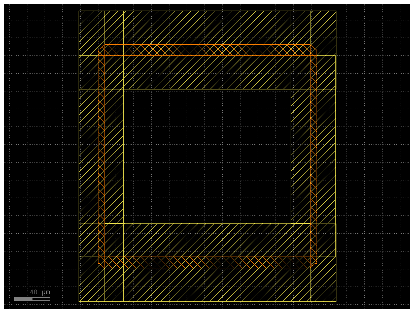

```python
blc = ihp.cells.branch_line_coupler(
    frequency=f,
    connection_length=connection_length_blc,
    signal_cross_section=signal_cross_section,
    ground_cross_section=ground_cross_section,
    Z0=Z0,
    e_r=e_r,
)
blc.plot()
```

The first branch line coupler (BLC_3) is added as a reference to the main component at the center position (0, 0).

```python
blc_3_ref = c.add_ref(blc)
```

## Corner Transition Piece

Instead of connecting directly to BLC ports, this design uses 45-degree diagonal slopes for area optimization. A corner transmission line piece with a 45° angle is created to smoothly transition from the corner port. This impedance-transforming corner connects the first BLC to the adjacent branch line coupler.

```
Calculated width: 3.42 um for Z0: 65.7 ohm
```

[figure not shown]

```python
corner = ihp.cells.tline_corner(
    signal_cross_section=signal_cross_section,
    ground_cross_section=ground_cross_section,
    Z0=Z0*1.314,
)

corner.plot()
corner_top_ref = c.add_ref(corner)
```

The first BLC (BLC_3) is positioned at the origin (0, 0) and connects the top corner piece to its port (e1) at 45 degrees. To verify the placement, the result is plotted.

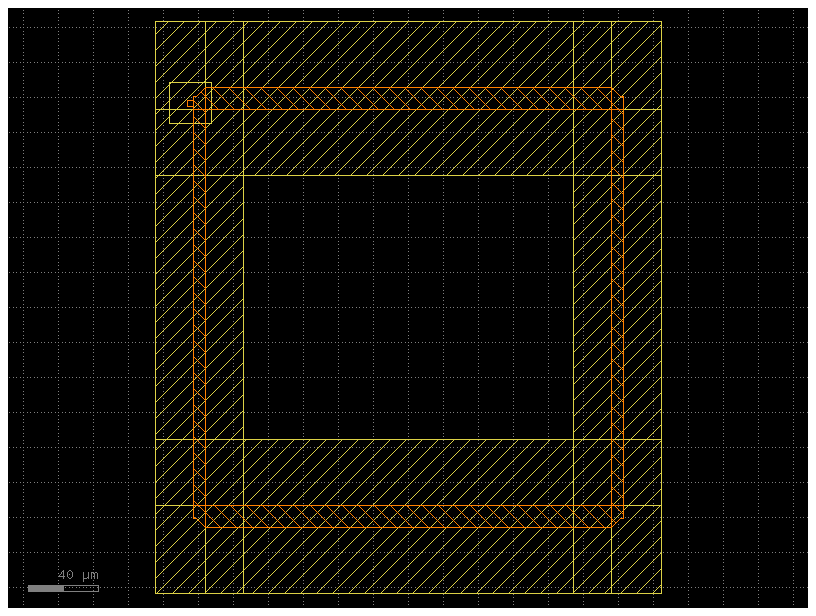

```python
blc_3_ref.center = (0, 0)
corner_top_ref.connect("e1", blc_3_ref.ports["e1"], allow_width_mismatch=True)

c.plot()
```

The second branch line coupler (BLC_1) is added at the top by connecting it to the top corner pieces port (e4).

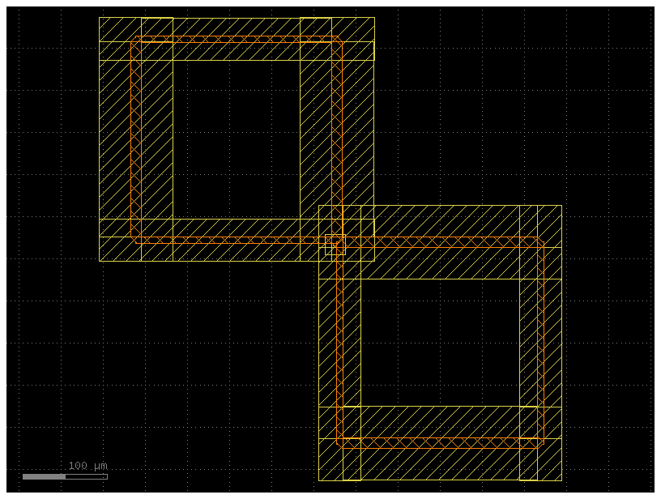

```python
blc_1_ref = c.add_ref(blc)
blc_1_ref.connect("e4", corner_top_ref.ports["e4"], allow_width_mismatch=True)

c.plot()
```

A second corner piece is added for the bottom branch, and the third BLC (BLC_2) is placed by connecting it through this corner piece to BLC_3's bottom port (e4).

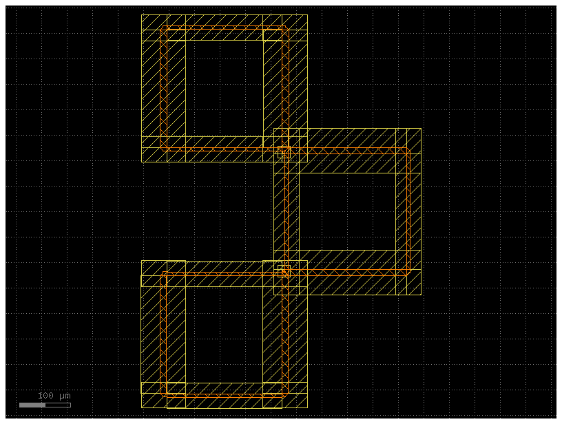

```python
corner_bot_ref = c.add_ref(corner)
corner_bot_ref.connect("e1", blc_3_ref.ports["e4"], allow_width_mismatch=True)
blc_2_ref = c.add_ref(blc)
blc_2_ref.connect("e1", corner_bot_ref.ports["e2"], allow_width_mismatch=True)

c.plot()
```

## Wilkinson Power Divider Design

Now, that the three BLCs form a corner structure, the second RF device to be created is a Wilkinson power divider (WPD). The WPD:

- is a custom add-on to the IHP-Open-PDK GDSFactory version integrated by us.
- is automatically generated from the frequency `f` and relative permittivity `e_r`.
- has branch lengths derived from the quarter-wavelength (λ/4).
- has branch widths determined by a formula that yields the desired characteristic impedance.
- serves as a 3 dB power divider. Since the WPD is not used for combining, the textbook resistor between the two output ports can be neglected. The target wavelength is anyway so small that the resistor would only have a negligible impact.
- scales all dimensions automatically with the operating frequency defined above.

The WPD is placed in the central space between BLC_1 (top) and BLC_2 (bottom) for an optimized area. This U-shaped power divider will split the RF signal from the bandpass filter into two paths, feeding the top and bottom BLC.

```
Calculated width: 7.2 um for Z0: 50 ohm
Calculated width: 2.5100000000000002 um for Z0: 70.71 ohm
Calculated Z0: 70.75520001248569 ohm for width: 2.51 um
Calculated width: 2.5100000000000002 um for Z0: 70.71 ohm
Calculated Z0: 70.75520001248569 ohm for width: 2.51 um
```

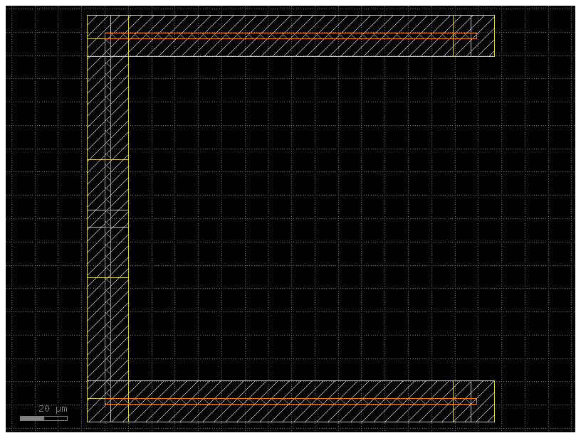

```python
wpd = ihp.cells.wilkinson_power_divider(
    frequency=f,
    connection_length=connection_length_wpd,
    signal_cross_section=signal_cross_section,
    ground_cross_section=ground_cross_section,
    Z0=Z0,
    e_r=e_r,
    shape="U",
)

wpd.plot()
```

```python
wpd.ports["e1"].orientation = 0
wpd_ref = c.add_ref(wpd)
```

## WPD-to-BLC Connections

The transmission line segments that connect the WPD outputs to the BLC ports are calculated as follows:

- Measure the vertical distance between BLC_1 and BLC_2
- Subtract the WPD height
- Divide by 2 to get the connection length for each side (top and bottom)

A single connection line segment is created, which is used for both the top and bottom connections to balance the layout.

```
Calculated width: 7.2 um for Z0: 50 ohm
```

[figure not shown]

```python
connection_length_wpd_blc_one_leg = blc_1_ref.ports["e1"].center[1] - blc_2_ref.ports["e4"].center[1] - (wpd_ref.ports["e2"].center[1] - wpd_ref.ports["e3"].center[1])

connection_wpd_blc = ihp.cells.tline(
    length=connection_length_wpd_blc_one_leg/2,
    signal_cross_section=signal_cross_section,
    ground_cross_section=ground_cross_section,
    Z0=Z0,
)

connection_wpd_blc.plot()
```

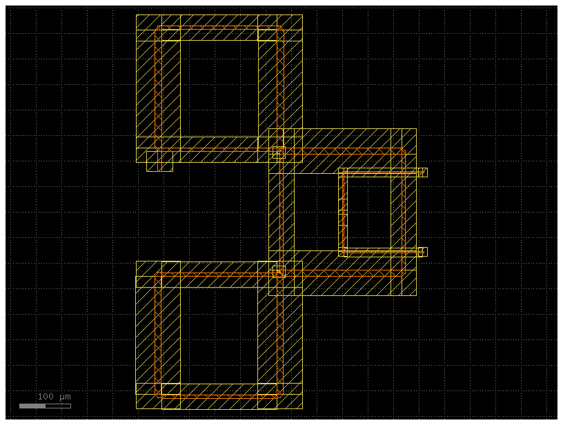

```python
connection_wpd_blc_top_ref = c.add_ref(connection_wpd_blc)
connection_wpd_blc_top_ref.connect("e1", blc_1_ref.ports["e1"])

c.plot()
```

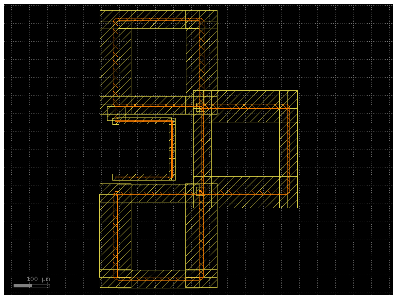

```python
wpd_ref.connect("e3", connection_wpd_blc_top_ref.ports["e2"])

c.plot()
```

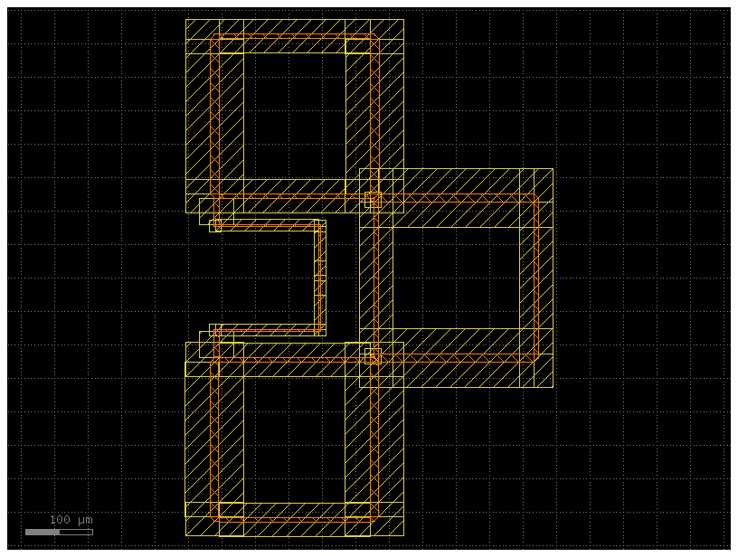

```python
connection_wpd_blc_bot_ref = c.add_ref(connection_wpd_blc)
connection_wpd_blc_bot_ref.connect("e1", blc_2_ref.ports["e4"])

wpd_ref.connect("e2", connection_wpd_blc_bot_ref.ports["e2"])

c.plot()
```

## Hairpin Coupled-Line Bandpass Filter Design

The third and last RF device to be created is a Hairpin Coupled-Line Bandpass Filter (BPF) with the above-defined filter parameters. The BPF:

- is a custom add-on to the IHP-Open-PDK GDSFactory version integrated by us.
- is automatically generated from the frequency `f` and relative permittivity `e_r`.
- provides the LO input to the six-port network.
- provides frequency selectivity to the LO input.
- uses inter-digital coupling (hairpin structure) for compact size.
- connects to the WPD input through a connection line segment.
- scales all dimensions automatically with the operating frequency defined above.

```
Calculated width: 7.2 um for Z0: 50 ohm
Calculated width: 7.2 um for Z0: 50 ohm
Calculated width: 7.2 um for Z0: 50 ohm
Calculated width: 7.13 um for Z0: 50.25 ohm
Calculated Z0: 50.26863690347976 ohm for width: 7.13 um
Calculated width: 7.2 um for Z0: 50 ohm
Calculated width: 7.2 um for Z0: 50.0 ohm
Calculated Z0: 50.03094234385018 ohm for width: 7.2 um
Calculated width: 7.2 um for Z0: 50 ohm
2026-04-14 19:49:45.624 | INFO     | kfactory.utils.fill:fill_tiled:278 - done with calculating fill regions for Unnamed_27
```

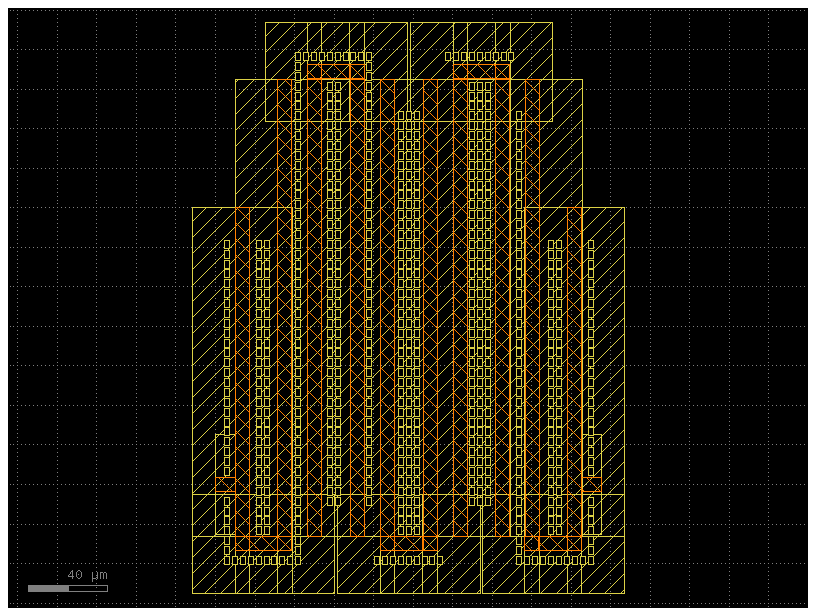

```python
bandpass_filter = ihp.cells.hairpin_coupled_line_bandpass_filter(
    frequency=f,
    bandwidth=bandwidth,
    order=order,
    filter_type=filter_type,
    ripple_dB=ripple_dB,
    connection_length=connection_length_bpf,
    signal_cross_section=signal_cross_section,
    ground_cross_section=ground_cross_section,
    Z0=Z0,
    e_r=e_r,
)

bandpass_filter_ref = c.add_ref(bandpass_filter)
bandpass_filter.plot()
```

```
Calculated width: 7.2 um for Z0: 50 ohm
```

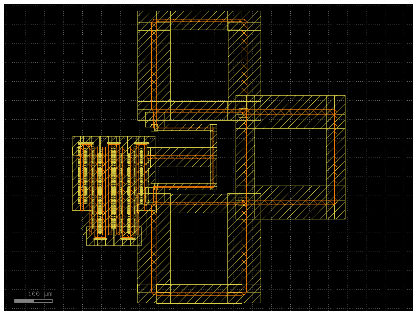

```python
connection_bpf_wpd = c.add_ref(ihp.cells.tline(
    length=connection_length_bpf_wpd,
    signal_cross_section=signal_cross_section,
    ground_cross_section=ground_cross_section,
    Z0=Z0,
))

connection_bpf_wpd.connect("e1", wpd_ref.ports["e1"])
bandpass_filter_ref.connect("e1", connection_bpf_wpd.ports["e2"])

c.plot()
```

With the RF devices complete, the next step is to add a termination resistor to the bottom right port of BLC_3, which is required for proper six-port operation. To utilize this, a 50 Ω silicided poly resistor is created, which is connected to TopMetal2 via a proper VIA stack. In the end, Metal5 no-fill regions are added to reduce parasitic capacitance.

```
Calculated width: 7.2 um for Z0: 50 ohm
via_stack PyCell placed successfully and GDS written.
```

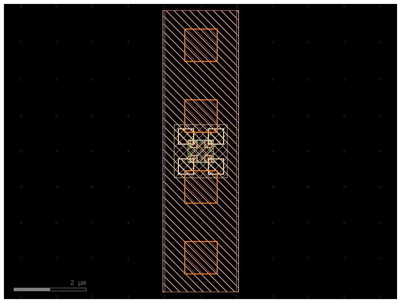

```python
connection_blc_R_termination = ihp.cells.straight(
    length=30, # manual meassurement to fit the design
    cross_section=signal_cross_section,
    width=ihp.cells.waveguides._calculate_width_from_Z0(Z0=Z0, e_r=e_r, signal_cross_section=signal_cross_section, ground_cross_section=ground_cross_section),
)
connection_blc_R_termination_ref = c.add_ref(connection_blc_R_termination)
connection_blc_R_termination_ref.connect("e1", blc_3_ref.ports["e3"])

via_M1_TM2 = ihp.cells.via_stack(
    top_layer="TopMetal2",
    bottom_layer="Metal1",
    vn_columns=2,
    vn_rows=2,
    vt1_columns=2,
    vt1_rows=2,
    vt2_columns=1,
    vt2_rows=4,
)

via_M1_TM2.plot()
via_M1_TM2.ports["top"].orientation = 180
via_M1_TM2.ports["bottom"].orientation = 180
via_M1_TM2_ref = c.add_ref(via_M1_TM2)
via_M1_TM2_ref.connect("top", connection_blc_R_termination_ref.ports["e2"], allow_width_mismatch=True)
```

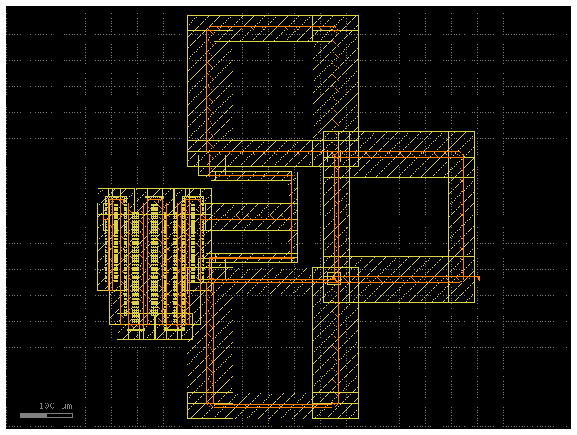

```python
c.plot()
```

```
rsil PyCell placed successfully and GDS written.
```

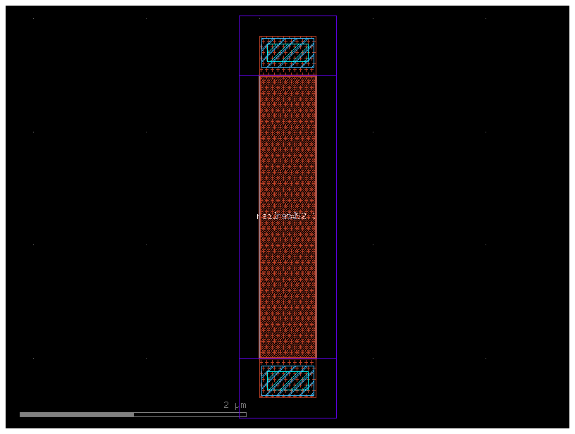

```python
R_termination = ihp.cells.rsil(
    resistance=Z0,
    width=0.5,
    length=2.5,
)
R_termination.plot()
```

```
via_stack PyCell placed successfully and GDS written.
```

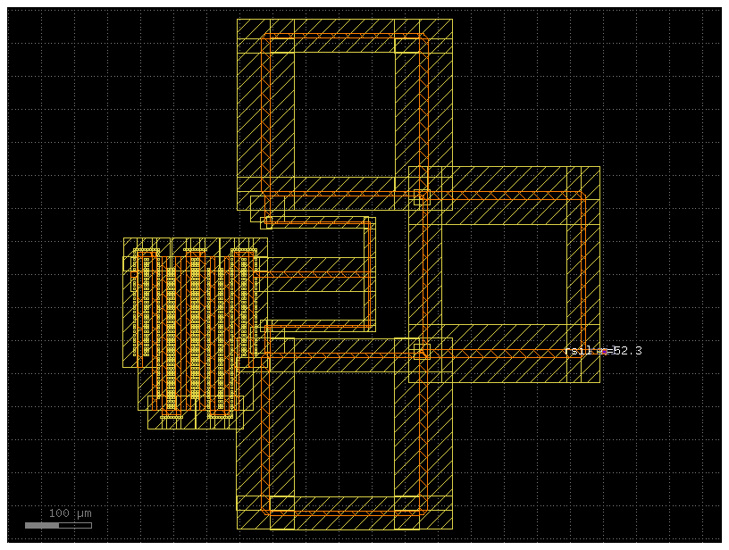

```python
R_termination_ref = c.add_ref(R_termination)
R_termination_ref.connect("e1", via_M1_TM2_ref.ports["bottom"], allow_width_mismatch=True, allow_layer_mismatch=True)

via_M1_M5 = ihp.cells.via_stack(
    top_layer="Metal5",
    bottom_layer="Metal1",
    vn_columns=2,
    vn_rows=2,
)
via_M1_M5.ports["top"].orientation = 180
via_M1_M5.ports["bottom"].orientation = 0
via_M1_M5_ref = c.add_ref(via_M1_M5)
via_M1_M5_ref.connect("bottom", R_termination_ref.ports["e2"], allow_width_mismatch=True, allow_layer_mismatch=True)

connection_R_termination_vss = ihp.cells.straight(
    length=10, # manual meassurement to fit the design
    cross_section=ground_cross_section,
    width=2, # manual meassurement to fit the design
)
connection_R_termination_vss_ref = c.add_ref(connection_R_termination_vss)
connection_R_termination_vss_ref.connect("e1", via_M1_M5_ref.ports["top"], allow_width_mismatch=True, allow_layer_mismatch=True)

c.plot()
```

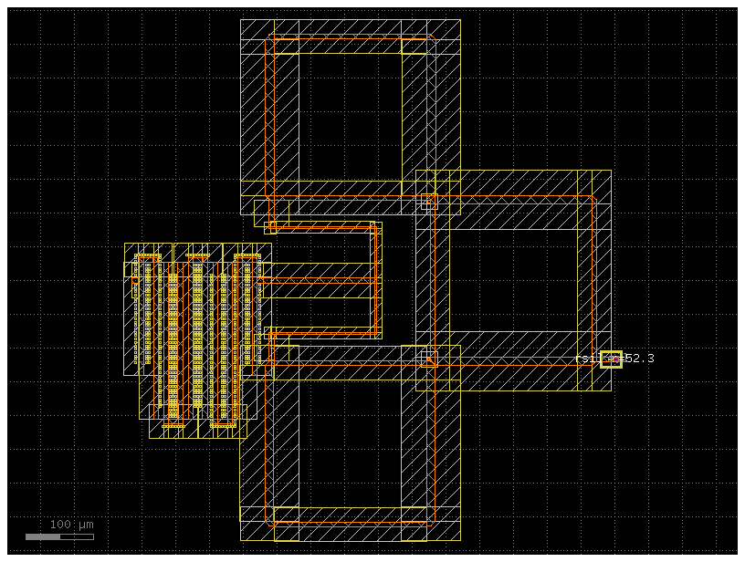

```python
# r termination metal5 nofill
c.add_ref(gf.components.rectangle(size=(connection_R_termination_vss_ref.xsize+20, connection_R_termination_vss_ref.ysize+20), layer=ihp.tech.LAYER.Metal5nofill)).center = connection_R_termination_vss_ref.center

c.plot()
```

```
Calculated width: 7.2 um for Z0: 50 ohm
```

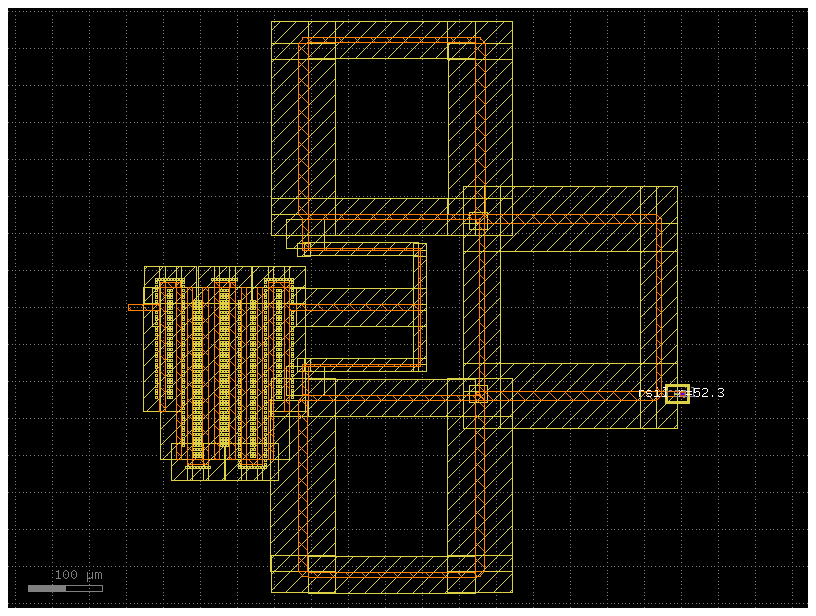

```python
connection_bpd_pad = c.add_ref(ihp.cells.straight(
    length=32,
    cross_section=signal_cross_section,
    width=ihp.cells.waveguides._calculate_width_from_Z0(Z0=Z0, e_r=e_r, signal_cross_section=signal_cross_section, ground_cross_section=ground_cross_section),
))
connection_bpd_pad.connect("e1", bandpass_filter_ref.ports["e2"], allow_width_mismatch=True)

c.plot()
```

## Probepads for LO Input

For the external LO input signal, a GSG (Ground-Signal-Ground) probepad array on the left side is added. This probepad:

- connects to the bandpass filter input path through a transmission line.
- provides controlled 50-ohm probing interface.
- includes a Metal5 no-fill region to minimize parasitic capacitance.

```
bondpad PyCell placed successfully and GDS written.
guardring PyCell placed successfully and GDS written.
bondpad PyCell placed successfully and GDS written.
```

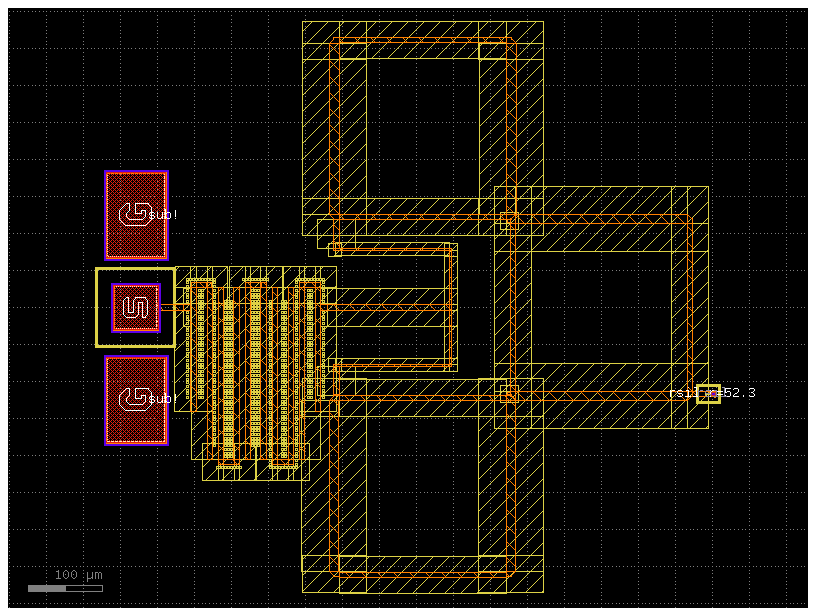

```python
probe_left = c.add_ref(ihp.cells.bondpad_array(config="GSG", pitch= 125, width_ground=120, width_signal=65, length_signal=65, signal_cross_section="topmetal1_routing", ground_cross_section="metal1_routing", ground_connection='psub')).rotate(-90)
probe_left.center = bandpass_filter.ports["e2"].center
probe_left.xmax = bandpass_filter.ports["e2"].center[0]-15
probe_left.connect("e1", connection_bpd_pad.ports["e2"], allow_width_mismatch=True)

c.add_ref(gf.components.rectangle(size=(105, 105), layer=ihp.tech.LAYER.Metal5nofill)).center = probe_left.center
c.plot()
```

## Probepads for RF Input

For the external RF input signal, a GSG (Ground-Signal-Ground) probepad array on the right side is added. This probepad:

- connects to the BLC_3 through a transmission line.
- is placed at the RF input node of the six-port network.
- includes a Metal5 no-fill region to minimize parasitic capacitance.

```
Calculated width: 7.2 um for Z0: 50 ohm
bondpad PyCell placed successfully and GDS written.
guardring PyCell placed successfully and GDS written.
```

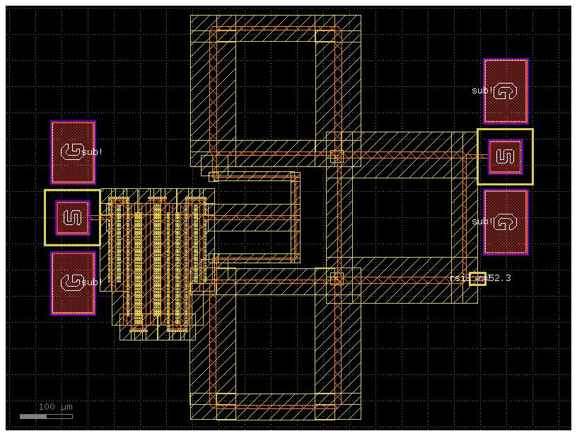

```python
connection_blc_pad = c.add_ref(ihp.cells.straight(
    length=42,
    cross_section=signal_cross_section,
    width=ihp.cells.waveguides._calculate_width_from_Z0(Z0=Z0, e_r=e_r, signal_cross_section=signal_cross_section, ground_cross_section=ground_cross_section),
))
connection_blc_pad.connect("e1", blc_3_ref.ports["e2"])

# probe pads right
probe_right = c.add_ref(ihp.cells.bondpad_array(config="GSG", pitch= 125, width_ground=125, width_signal=65, length_signal=65, signal_cross_section="topmetal1_routing", ground_cross_section="metal1_routing", ground_connection='psub')).rotate(-90)
probe_right.connect("e1", connection_blc_pad.ports["e2"], allow_width_mismatch=True)

c.add_ref(gf.components.rectangle(size=(105, 105), layer=ihp.tech.LAYER.Metal5nofill)).center = probe_right.center

c.plot()
```

## Measurement Bondpads for Power Detectors

The RF network is now completed, but the six-port outputs feed into the above-designed power detectors, which demodulate the signal for direct waveform sampling and measurements. Since we are dealing with "low" frequency signals now, we can add bondpads instead of probepads, which are then bonded to a PCB for convenient measurement setup.

The top and bottom bondpad arrays are arranged as an SSGSGSS configuration and have the following pinout: VREF, VOUT, VSS, VDD, VSS, VOUT, VREF This means that per bondpad array, two power detectors are connected. Metal5 rectangles are placed around each signal bondpad to minimize parasitic capacitance.

```
bondpad PyCell placed successfully and GDS written.
bondpad PyCell placed successfully and GDS written.
guardring PyCell placed successfully and GDS written.
```

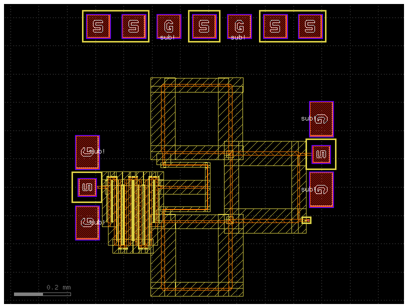

```python
# probe pads top
_ = c.center
probe_top = c.add_ref(ihp.cells.bondpad_array(config="SSGSGSS", signal_cross_section="topmetal1_routing", ground_cross_section="metal1_routing", ground_connection='psub'))
probe_top.center = _
probe_top.ymax = c.ymax + 225

# no fill VDD
c.add_ref(gf.components.rectangle(size=(110, 110), layer=ihp.tech.LAYER.Metal5nofill)).center = probe_top.center

# no fill top
no_fill_top_left = c.add_ref(gf.components.rectangle(size=(85+125+25, 110), layer=ihp.tech.LAYER.Metal5nofill))
no_fill_top_left.xmin = probe_top.xmin-(110-85)/2
no_fill_top_left.ymin = probe_top.ymin-(110-85)/2

no_fill_top_right = c.add_ref(gf.components.rectangle(size=(85+125+25, 110), layer=ihp.tech.LAYER.Metal5nofill))
no_fill_top_right.xmax = probe_top.xmax+(110-85)/2
no_fill_top_right.ymin = probe_top.ymin-(110-85)/2

c.plot()
```

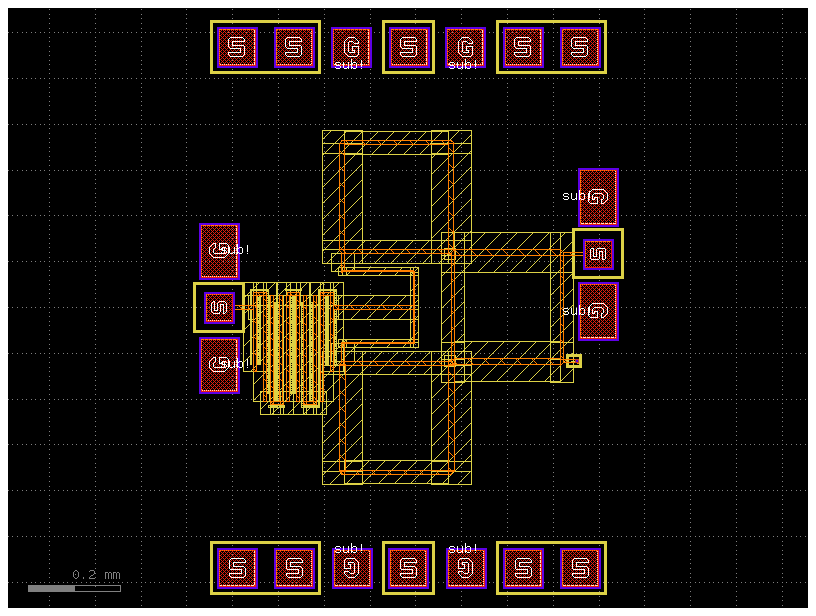

```python
# probe pads bottom
probe_bottom = c.add_ref(ihp.cells.bondpad_array(config="SSGSGSS", signal_cross_section="topmetal1_routing", ground_cross_section="metal1_routing", ground_connection='psub')).rotate(180)
probe_bottom.center = _
probe_bottom.ymin = c.ymin - 225

# no fill VDD
c.add_ref(gf.components.rectangle(size=(110, 110), layer=ihp.tech.LAYER.Metal5nofill)).center = probe_bottom.center

# no fill bottom
no_fill_bottom_left = c.add_ref(gf.components.rectangle(size=(85+125+25, 110), layer=ihp.tech.LAYER.Metal5nofill))
no_fill_bottom_left.xmin = probe_bottom.xmin-(110-85)/2
no_fill_bottom_left.ymin = probe_bottom.ymin-(110-85)/2

no_fill_bottom_right = c.add_ref(gf.components.rectangle(size=(85+125+25, 110), layer=ihp.tech.LAYER.Metal5nofill))
no_fill_bottom_right.xmax = probe_bottom.xmax+(110-85)/2
no_fill_bottom_right.ymin = probe_bottom.ymin-(110-85)/2

c.plot()
```

## Instantiate Power Detector Module

An instance of the above-defined power detector module (powdet_sbd) is created. This detector will be used as the base template for all four detector channels on the chip.

[output not shown]

```
┏━━━━━━┳━━━━━━━┳━━━━━━━━━━━━━┳━━━━━━━━━━━━━━━━━━━━━━━━━━┳━━━━━━━━━━━━━━━━━━━━━━━━━━━┳━━━━━━━━━━━━┓
┃ name ┃ width ┃ orientation ┃ layer                    ┃ center                    ┃ port_type  ┃
┡━━━━━━╇━━━━━━━╇━━━━━━━━━━━━━╇━━━━━━━━━━━━━━━━━━━━━━━━━━╇━━━━━━━━━━━━━━━━━━━━━━━━━━━╇━━━━━━━━━━━━┩
│ vout │ 0.7   │ 90.0        │ Metal4drawing (50/0)     │ (7.37, 40.84)             │ electrical │
│ vref │ 2.0   │ 90.0        │ Metal3drawing (30/0)     │ (5.47, 48.68)             │ electrical │
│ rfin │ 7.78  │ 270.0       │ TopMetal2drawing (134/0) │ (0.0, 0.0)                │ electrical │
│ vss  │ 11.2  │ 90.0        │ Metal5drawing (67/0)     │ (70.32000000000001, 79.8) │ electrical │
│ vdd  │ 10.08 │ 90.0        │ TopMetal1drawing (126/0) │ (23.44, 79.8)             │ electrical │
└──────┴───────┴─────────────┴──────────────────────────┴───────────────────────────┴────────────┘
```

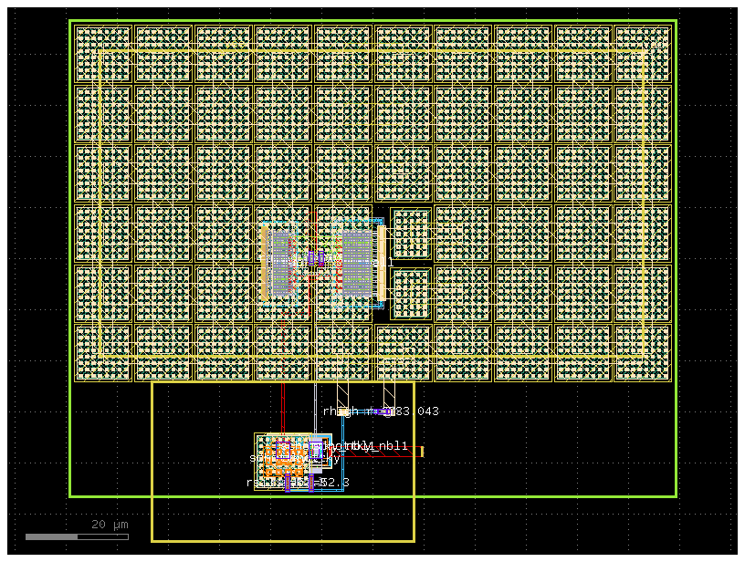

```python
pd = powdet_sbd()
pd.plot()
```

## Place and Connect First Power Detector (PD1)

PD1 is instantiated using a mirrored detector variant and is placed by connectivity:

- Create a short RF interconnect line (`connection_rfin`)
- Connect that line to `blc_1_ref` port `e2`
- Attach PD1 `rfin` to the interconnect output

This anchors the PD1 location from the RF topology and keeps placement robust to geometry changes.

```
Calculated width: 7.2 um for Z0: 50 ohm
```

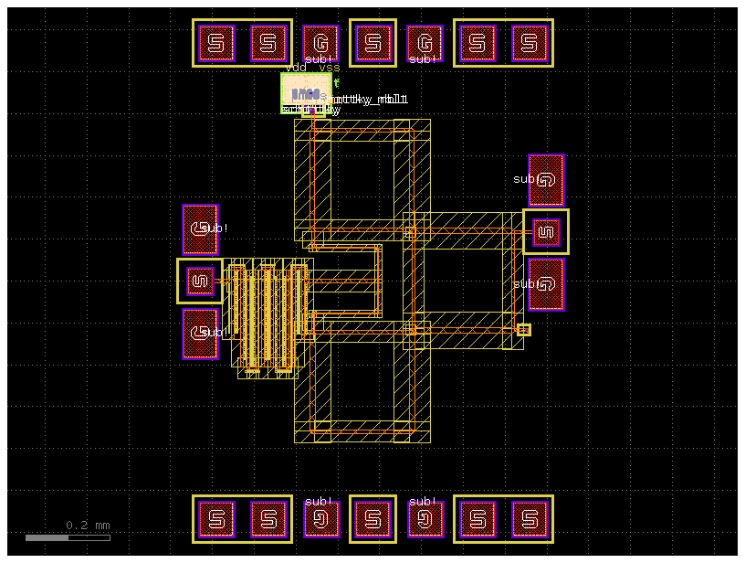

```python
pd1_ref = c.add_ref(pd).mirror_x()
connection_rfin = ihp.cells.straight(
    length=wavelength/22,
    cross_section=signal_cross_section,
    width=ihp.cells.waveguides._calculate_width_from_Z0(Z0=Z0, e_r=e_r, signal_cross_section=signal_cross_section, ground_cross_section=ground_cross_section),
)
connection_rfin_ref = c.add_ref(connection_rfin)
connection_rfin_ref.connect("e1", blc_1_ref.ports["e2"])
pd1_ref.connect("rfin", connection_rfin_ref.ports["e2"], allow_width_mismatch=True)
c.plot()
```

PD1 is now topology-placed via RF port connections. Next, route its supply and output nets to the top bondpads.

The first step connects PD1 `vdd` using the GDSFactory built-in electrical bundle router.

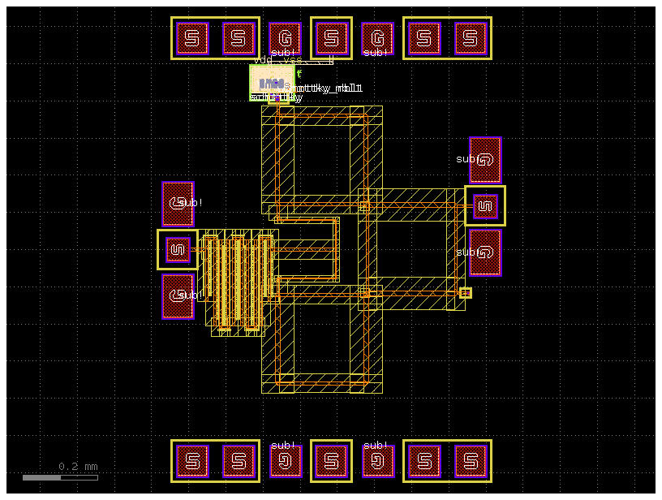

```python
route_pd1_vdd = gf.routing.route_bundle_electrical(
    component=c,
    ports1=[pd1_ref.ports["vdd"]],
    ports2=[probe_top.ports["e4"]],
    route_width=8,    # adjust for thicker connections
    layer=ihp.tech.LAYER.TopMetal1drawing,
    start_straight_length=10,
    allow_layer_mismatch=True,
    allow_width_mismatch=True,
    auto_taper=False,
    separation=0,
)
c.plot()
```

Next, PD1 `vss` is connected to the top bondpad using a Metal5 electrical route with a straight lead for clean routing.

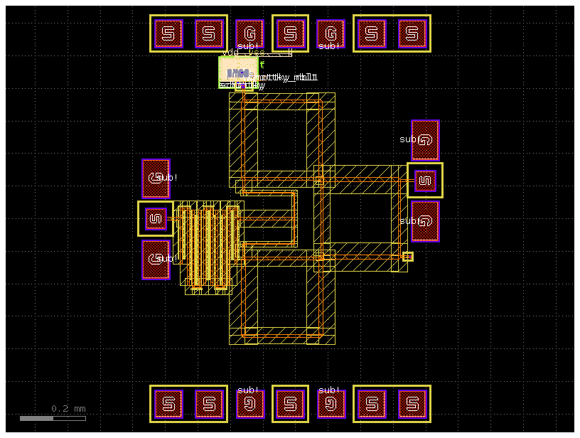

```python
route_pd1_vss = gf.routing.route_bundle_electrical(
    component=c,
    ports1=[pd1_ref.ports["vss"]],
    ports2=[probe_top.ports["e3"]],
    route_width=2,    # adjust for thicker connections
    layer=ihp.tech.LAYER.Metal5drawing,
    start_straight_length=10, # 10 or longer, to avoid routing through itself
    allow_layer_mismatch=True,
    allow_width_mismatch=True,
    auto_taper=False,
    separation=0,
)
c.plot()
```

Afterwards, PD1 `vout` is connected to the top bondpad through a Metal4 route using a TopMetal1-to-Metal4 VIA stack.

```
via_stack PyCell placed successfully and GDS written.
```

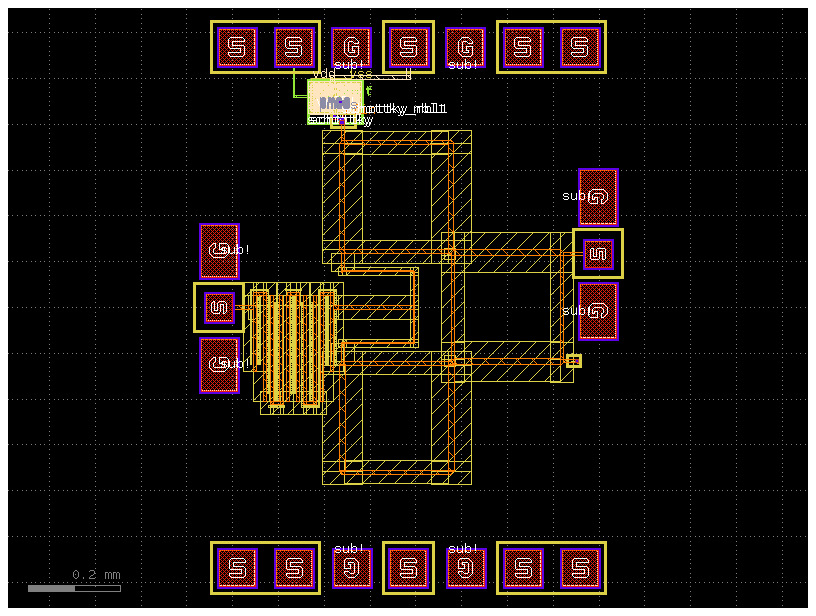

```python
via_M4_TM1 = ihp.cells.via_stack(
    top_layer="TopMetal1",
    bottom_layer="Metal4",
    vn_columns=10,
    vn_rows=3,
    vt1_columns=5,
    vt1_rows=1,
)
via_M4_TM1.ports["top"].orientation = 90
via_M4_TM1.ports["bottom"].orientation = 270
via_M4_TM1_ref = c.add_ref(via_M4_TM1)
via_M4_TM1_ref.connect("top", probe_top.ports["e2"], allow_width_mismatch=True, allow_layer_mismatch=True)
via_M4_TM1_ref.move((0, via_M4_TM1_ref.ysize/2))
route_pd1_vout = gf.routing.route_bundle_electrical(
    component=c,
    ports1=[pd1_ref.ports["vout"]],
    ports2=[via_M4_TM1_ref.ports["bottom"]],
    route_width=4,    # adjust for thicker connections
    layer=ihp.tech.LAYER.Metal4drawing,
    start_straight_length=10, # 10 or longer, to avoid routing through itself
    allow_layer_mismatch=True,
    allow_width_mismatch=True,
    auto_taper=False,
    separation=0,
)
c.plot()
```

Finally, PD1 `vref` is connected to the top bondpad through a Metal3 route using a TopMetal1-to-Metal3 VIA stack.

```
via_stack PyCell placed successfully and GDS written.
```

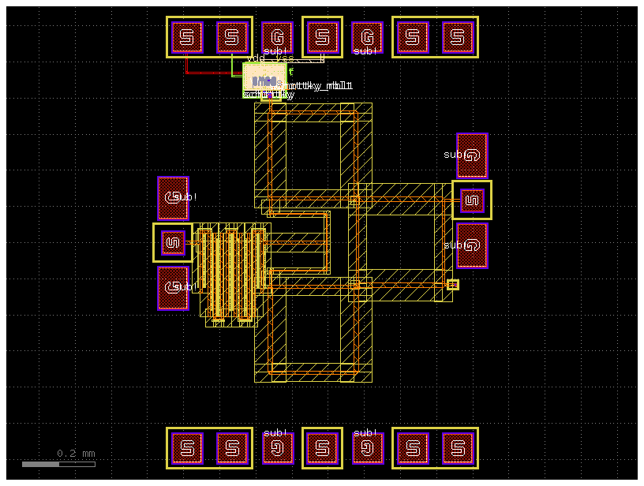

```python
via_M3_TM1 = ihp.cells.via_stack(
    top_layer="TopMetal1",
    bottom_layer="Metal3",
    vn_columns=10,
    vn_rows=3,
    vt1_columns=5,
    vt1_rows=1,
)
via_M3_TM1.ports["top"].orientation = 90
via_M3_TM1.ports["bottom"].orientation = 270
via_M3_TM1_ref = c.add_ref(via_M3_TM1)
via_M3_TM1_ref.connect("top", probe_top.ports["e1"], allow_width_mismatch=True, allow_layer_mismatch=True)
via_M3_TM1_ref.move((0, via_M3_TM1_ref.ysize/2))
route_pd1_vref = gf.routing.route_bundle_electrical(
    component=c,
    ports1=[pd1_ref.ports["vref"]],
    ports2=[via_M3_TM1_ref.ports["bottom"]],
    route_width=4,    # adjust for thicker connections
    layer=ihp.tech.LAYER.Metal3drawing,
    start_straight_length=10, # 10 or longer, to avoid routing through itself
    allow_layer_mismatch=True,
    allow_width_mismatch=True,
    auto_taper=False,
    separation=0,
)
c.plot()
```

The RF and bias routing for PD1 is completed. Next, instantiate and route PD2 using the complementary orientation and adjacent BLC branch.

## Place and Connect Second Power Detector (PD2)

PD2 is instantiated in its non-mirrored orientation and is placed by connectivity:

- Connect an RF interconnect from `blc_1_ref` port `e3` to PD2 `rfin`
- Route `vdd` and `vss` to top bondpads
- Route `vout` and `vref` through Metal4/Metal3 paths using via stacks to top bondpads

This keeps PD2 aligned with the surrounding network as dimensions scale.

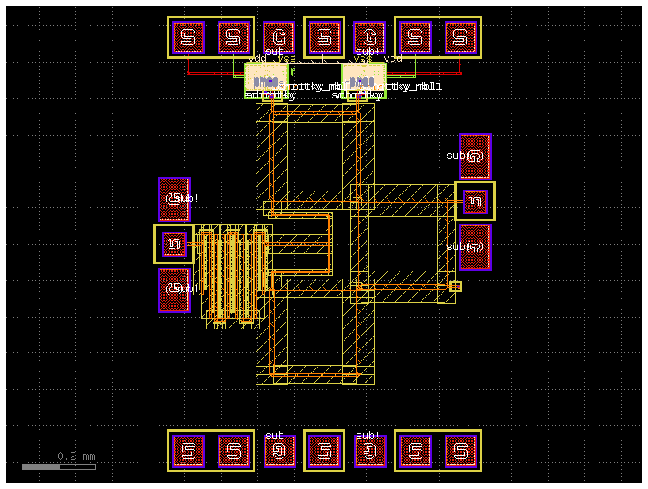

```python
pd2_ref = c.add_ref(pd)
connection_rfin_ref = c.add_ref(connection_rfin)
connection_rfin_ref.connect("e1", blc_1_ref.ports["e3"])
pd2_ref.connect("rfin", connection_rfin_ref.ports["e2"], allow_width_mismatch=True)

# vdd connection of pd2 to probe top
route_pd2_vdd = gf.routing.route_bundle_electrical(
    component=c,
    ports1=[pd2_ref.ports["vdd"]],
    ports2=[probe_top.ports["e4"]],
    route_width=8,    # adjust for thicker connections
    layer=ihp.tech.LAYER.TopMetal1drawing,
    start_straight_length=10,
    allow_layer_mismatch=True,
    allow_width_mismatch=True,
    auto_taper=False,
    separation=0,
)
# vss connection of pd2 to probe top
route_pd2_vss = gf.routing.route_bundle_electrical(
    component=c,
    ports1=[pd2_ref.ports["vss"]],
    ports2=[probe_top.ports["e5"]],
    route_width=2,    # adjust for thicker connections
    layer=ihp.tech.LAYER.Metal5drawing,
    start_straight_length=10, # 10 or longer, to avoid routing through itself
    allow_layer_mismatch=True,
    allow_width_mismatch=True,
    auto_taper=False,
    separation=0,
)
# vout connection of pd2 to probe top
via_M4_TM1_ref = c.add_ref(via_M4_TM1)
via_M4_TM1_ref.connect("top", probe_top.ports["e6"], allow_width_mismatch=True, allow_layer_mismatch=True)
via_M4_TM1_ref.move((0, via_M4_TM1_ref.ysize/2))
route_pd2_vout = gf.routing.route_bundle_electrical(
    component=c,
    ports1=[pd2_ref.ports["vout"]],
    ports2=[via_M4_TM1_ref.ports["bottom"]],
    route_width=4,    # adjust for thicker connections
    layer=ihp.tech.LAYER.Metal4drawing,
    start_straight_length=10, # 10 or longer, to avoid routing through itself
    allow_layer_mismatch=True,
    allow_width_mismatch=True,
    auto_taper=False,
    separation=0,
)
# vref connection of pd2 to probe top
via_M3_TM1_ref = c.add_ref(via_M3_TM1)
via_M3_TM1_ref.connect("top", probe_top.ports["e7"], allow_width_mismatch=True, allow_layer_mismatch=True)
via_M3_TM1_ref.move((0, via_M3_TM1_ref.ysize/2))
route_pd2_vref = gf.routing.route_bundle_electrical(
    component=c,
    ports1=[pd2_ref.ports["vref"]],
    ports2=[via_M3_TM1_ref.ports["bottom"]],
    route_width=4,    # adjust for thicker connections
    layer=ihp.tech.LAYER.Metal3drawing,
    start_straight_length=10, # 10 or longer, to avoid routing through itself
    allow_layer_mismatch=True,
    allow_width_mismatch=True,
    auto_taper=False,
    separation=0,
)

c.plot()
```

## Place and Connect Third Power Detector (PD3)

PD3 is instantiated with both mirror operations (`mirror_y().mirror_x()`), then placed through net connectivity:

- Drive `rfin` from `blc_2_ref` port `e3` through the RF interconnect
- Route `vdd`, `vss`, `vout`, and `vref` to the bottom bondpads
- Use VIA-assisted transitions for `vout` (Metal4) and `vref` (Metal3)

PD3 placement is derived from mirror transforms plus port connections, so it adapts automatically with layout changes.

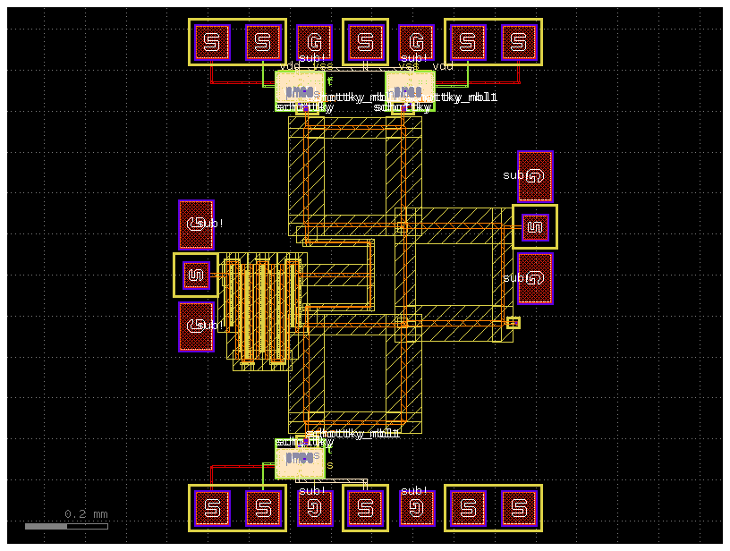

```python
pd3_ref = c.add_ref(pd).mirror_y().mirror_x()
connection_rfin_ref = c.add_ref(connection_rfin)
connection_rfin_ref.connect("e1", blc_2_ref.ports["e3"])
pd3_ref.connect("rfin", connection_rfin_ref.ports["e2"], allow_width_mismatch=True)

# vdd connection of pd3 to probe bottom
route_pd3_vdd = gf.routing.route_bundle_electrical(
    component=c,
    ports1=[pd3_ref.ports["vdd"]],
    ports2=[probe_bottom.ports["e4"]],
    route_width=8,    # adjust for thicker connections
    layer=ihp.tech.LAYER.TopMetal1drawing,
    start_straight_length=10,
    allow_layer_mismatch=True,
    allow_width_mismatch=True,
    auto_taper=False,
    separation=0,
)
# vss connection of pd3 to probe bottom
route_pd3_vss = gf.routing.route_bundle_electrical(
    component=c,
    ports1=[pd3_ref.ports["vss"]],
    ports2=[probe_bottom.ports["e5"]],
    route_width=2,    # adjust for thicker connections
    layer=ihp.tech.LAYER.Metal5drawing,
    start_straight_length=10, # 10 or longer, to avoid routing through itself
    allow_layer_mismatch=True,
    allow_width_mismatch=True,
    auto_taper=False,
    separation=0,
)
# vout connection of pd3 to probe bottom
via_M4_TM1_ref = c.add_ref(via_M4_TM1)
via_M4_TM1_ref.connect("top", probe_bottom.ports["e6"], allow_width_mismatch=True, allow_layer_mismatch=True)
via_M4_TM1_ref.move((0, -via_M4_TM1_ref.ysize/2))

route_pd3_vout = gf.routing.route_bundle_electrical(
    component=c,
    ports1=[pd3_ref.ports["vout"]],
    ports2=[via_M4_TM1_ref.ports["bottom"]],
    route_width=4,    # adjust for thicker connections
    layer=ihp.tech.LAYER.Metal4drawing,
    start_straight_length=10, # 10 or longer, to avoid routing through itself
    allow_layer_mismatch=True,
    allow_width_mismatch=True,
    auto_taper=False,
    separation=0,
)
# vref connection of pd3 to probe bottom
via_M3_TM1_ref = c.add_ref(via_M3_TM1)
via_M3_TM1_ref.connect("top", probe_bottom.ports["e7"], allow_width_mismatch=True, allow_layer_mismatch=True)
via_M3_TM1_ref.move((0, -via_M3_TM1_ref.ysize/2))
route_pd3_vref = gf.routing.route_bundle_electrical(
    component=c,
    ports1=[pd3_ref.ports["vref"]],
    ports2=[via_M3_TM1_ref.ports["bottom"]],
    route_width=4,    # adjust for thicker connections
    layer=ihp.tech.LAYER.Metal3drawing,
    start_straight_length=10, # 10 or longer, to avoid routing through itself
    allow_layer_mismatch=True,
    allow_width_mismatch=True,
    auto_taper=False,
    separation=0,
)
c.plot()
```